# Torsten Testing on an M2

Author

Casey Davis

Published

January 18, 2024

# 1 Introduction

# 2 Some Examples

## 2.1 Simulate from My Models

I’m starting out with simulations, mainly because it’s simpler and faster.

### 2.1.1 One-Compartment Oral with Lognormal Error

The following code simulates with Stan + Torsten with an analytical solution, linear ODE solution, and general ODE solution using code I’ve written in the past, and then also a simulation with mrgsolve as a comparison.

```r
TVCL <- 0.5
TVVC <- 12
TVKA <- 1

omega_cl <- 0
omega_vc <- 0
omega_ka <- 0

R <- diag(rep(1, times = 3))

sigma <- 0.2

dosing_data <- expand.ev(ID = 1, addl = 6, ii = 24,
                         cmt = 1, amt = 200, ss = 0, tinf = 0,
                         evid = 1) %>%
  as_tibble() %>%
  rename_all(toupper) %>%
  select(ID, TIME, everything())

times_to_simulate <- c(0.25, seq(0.5, 24*7, by = 0.5))

nonmem_data_simulate <- dosing_data %>%
  group_by(ID) %>%
  slice(rep(1, times = length(times_to_simulate))) %>%
  mutate(AMT = 0,
         ADDL = 0,
         II = 0,
         CMT = 2,
         EVID = 0,
         TIME = times_to_simulate) %>%
  ungroup() %>%
  bind_rows(dosing_data) %>%
  arrange(ID, TIME, AMT)

n_subjects <- nonmem_data_simulate %>%  # number of individuals to simulate
  distinct(ID) %>%
  count() %>%
  deframe()

n_total <- nrow(nonmem_data_simulate) # total number of time points at which to predict

subj_start <- nonmem_data_simulate %>%
  mutate(row_num = 1:n()) %>%
  group_by(ID) %>%
  slice_head(n = 1) %>%
  ungroup() %>%
  select(row_num) %>%
  deframe()

subj_end <- c(subj_start[-1] - 1, n_total)

stan_data <- list(n_subjects = n_subjects,
                  n_total = n_total,
                  time = nonmem_data_simulate$TIME,
                  amt = nonmem_data_simulate$AMT,
                  cmt = nonmem_data_simulate$CMT,
                  evid = nonmem_data_simulate$EVID,
                  rate = nonmem_data_simulate$RATE,
                  ii = nonmem_data_simulate$II,
                  addl = nonmem_data_simulate$ADDL,
                  ss = nonmem_data_simulate$SS,
                  subj_start = subj_start,
                  subj_end = subj_end,
                  TVCL = TVCL,
                  TVVC = TVVC,
                  TVKA = TVKA,
                  omega_cl = omega_cl,
                  omega_vc = omega_vc,
                  omega_ka = omega_ka,
                  R = R,
                  sigma = sigma,
                  solver = 1) # analytical = 1, mat exp = 2, rk45 = 3

model <- cmdstan_model(
  here::here("M3/depot_1cmt_linear/Stan/Simulate/depot_1cmt_exp.stan"))
```

[output not shown]

[output not shown]

```
1 warning generated.
```

```r
model$print()
```

```
// First Order Absorption (oral/subcutaneous)
// One-compartment PK Model
// IIV on CL, VC, KA
// exponential error - DV = IPRED*exp(eps)
// Any of analytical, matrix-exponential, or general ODE solution using Torsten

functions{

  vector depot_1cmt_ode(real t, vector y, array[] real params,
                        array[] real x_r, array[] int x_i){

    real cl = params[1];
    real vc = params[2];
    real ka = params[3];
    real ke = cl/vc;

    vector[2] dydt;

    dydt[1] = -ka*y[1];           // depot
    dydt[2] = ka*y[1] - ke*y[2];  // central

    return dydt;
  }

}
data{

  int n_subjects;
  int n_total;

  array[n_total] real amt;
  array[n_total] int cmt;
  array[n_total] int evid;
  array[n_total] real rate;
  array[n_total] real ii;
  array[n_total] int addl;
  array[n_total] int ss;
  array[n_total] real time;

  array[n_subjects] int subj_start;
```

[output cut: 115 more lines]

```

      ipred[subj_start[j]:subj_end[j]] =
                                x_ipred[subj_start[j]:subj_end[j], 2] ./ VC[j];

    }

    for(i in 1:n_total){
      if(ipred[i] == 0){
         dv[i] = 0;
      }else{
        dv[i] = lognormal_rng(log(ipred[i]), sigma);
      }
    }
  }
}
```

```r
simulated_data <- model$sample(data = stan_data,
                               fixed_param = TRUE,
                               seed = 1123,
                               iter_warmup = 0,
                               iter_sampling = 1,
                               chains = 1,
                               parallel_chains = 1)

data_analytical <- simulated_data$draws(c("dv", "ipred")) %>%
  spread_draws(dv[i], ipred[i]) %>%
  ungroup() %>%
  inner_join(nonmem_data_simulate %>%
               mutate(i = 1:n()),
             by = "i") %>%
  select(ID, AMT, II, ADDL, RATE, CMT, EVID, SS, TIME,
         DV = "dv", IPRED = "ipred") %>%
  mutate(LLOQ = 1e-6,
         BLOQ = case_when(EVID == 1 ~ NA_real_,
                          DV <= LLOQ ~ 1,
                          DV > LLOQ ~ 0,
                          TRUE ~ NA_real_),
         DV = if_else(EVID == 1 | BLOQ == 1, NA_real_, DV),
         MDV = if_else(is.na(DV), 1, 0)) %>%
  relocate(DV, .after = last_col()) %>%
  relocate(TIME, .before = DV) %>%
  mutate(solver = "analytical")


stan_data$solver <- 2
simulated_data <- model$sample(data = stan_data,
                               fixed_param = TRUE,
                               seed = 1123,
                               iter_warmup = 0,
                               iter_sampling = 1,
                               chains = 1,
                               parallel_chains = 1)

data_mat_exp <- simulated_data$draws(c("dv", "ipred")) %>%
  spread_draws(dv[i], ipred[i]) %>%
  ungroup() %>%
  inner_join(nonmem_data_simulate %>%
               mutate(i = 1:n()),
             by = "i") %>%
  select(ID, AMT, II, ADDL, RATE, CMT, EVID, SS, TIME,
         DV = "dv", IPRED = "ipred") %>%
  mutate(LLOQ = 1e-6,
         BLOQ = case_when(EVID == 1 ~ NA_real_,
                          DV <= LLOQ ~ 1,
                          DV > LLOQ ~ 0,
                          TRUE ~ NA_real_),
         DV = if_else(EVID == 1 | BLOQ == 1, NA_real_, DV),
         MDV = if_else(is.na(DV), 1, 0)) %>%
  relocate(DV, .after = last_col()) %>%
  relocate(TIME, .before = DV) %>%
  mutate(solver = "mat_exp")


stan_data$solver <- 3
simulated_data <- model$sample(data = stan_data,
                               fixed_param = TRUE,
                               seed = 1123,
                               iter_warmup = 0,
                               iter_sampling = 1,
                               chains = 1,
                               parallel_chains = 1)

data_rk45 <- simulated_data$draws(c("dv", "ipred")) %>%
  spread_draws(dv[i], ipred[i]) %>%
  ungroup() %>%
  inner_join(nonmem_data_simulate %>%
               mutate(i = 1:n()),
             by = "i") %>%
  select(ID, AMT, II, ADDL, RATE, CMT, EVID, SS, TIME,
         DV = "dv", IPRED = "ipred") %>%
  mutate(LLOQ = 1e-6,
         BLOQ = case_when(EVID == 1 ~ NA_real_,
                          DV <= LLOQ ~ 1,
                          DV > LLOQ ~ 0,
                          TRUE ~ NA_real_),
         DV = if_else(EVID == 1 | BLOQ == 1, NA_real_, DV),
         MDV = if_else(is.na(DV), 1, 0)) %>%
  relocate(DV, .after = last_col()) %>%
  relocate(TIME, .before = DV) %>%
  mutate(solver = "rk45")

## Now do it with mrgsolve to check

mod <- mread(here::here("M3/depot_1cmt_linear/mrgsolve/depot_1cmt_exp.cpp"))

data_mrgsolve <- mod %>%
  param(tibble(CL = TVCL,
               VC = TVVC,
               KA = TVKA,
               F1 = 1,
               LAGTIME = 0)) %>%
  data_set(dosing_data) %>%
  mrgsim_df(tgrid = times_to_simulate) %>%
  as_tibble() %>%
  mutate(solver = "mrgsolve")
```

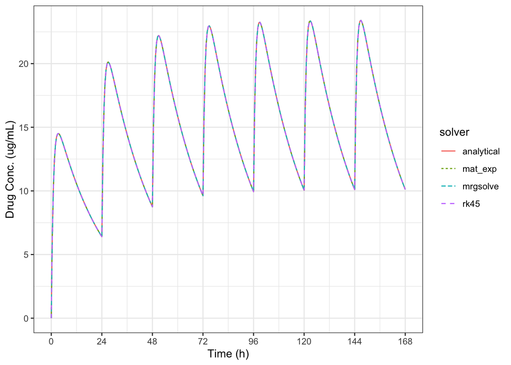

```r
mget(str_subset(ls(), "^data_")) %>%
  bind_rows() %>%
  ggplot(aes(x = TIME, y = IPRED, color = solver)) +
  geom_line(aes(linetype = solver)) +
  theme_bw() +
  scale_x_continuous(name = "Time (h)",
                     breaks = seq(0, 168, by = 24),
                     labels = seq(0, 168, by = 24)) +
  scale_y_continuous(name = "Drug Conc. (ug/mL)")
```

So you can see for the M2, the analytical soultion, linear ODE, general ODE, and mrgsolve simulations are all the same, in contrast with the M3 where the analytical solution was a vector of zeros.

### 2.1.2 Two-Compartment IV with Proportional Error

The following code simulates with Stan + Torsten with an analytical solution, linear ODE solution, and general ODE solution using code I’ve written in the past, and then also a simulation with mrgsolve as a comparison.

```r
TVCL <- 0.25  # L/d
TVVC <- 3     # L
TVQ <- 1      # L/d
TVVP <- 4     # L

omega_cl <- 0
omega_vc <- 0
omega_q <- 0
omega_vp <- 0

R <- diag(rep(1, times = 4))

sigma_p <- 0.2
sigma_a <- 0.05

cor_p_a <- 0

solver <- 1 # analytical = 1, mat exp = 2, rk45 = 3

# If using Torsten's analytical solver, dose into the second compartment
# (cmt = 2). If using matrix-exponential or ODE, then dose into the first
# compartment (cmt = 1)
dosing_data <- expand.ev(ID = 1, addl = 5, ii = 14,
                         cmt = 2, amt = 400, ss = 0,
                         tinf = 1/24, evid = 1) %>%
  as_tibble() %>%
  mutate(cmt = if_else(solver == 1, 2, 1)) %>%
  rename_all(toupper) %>%
  select(ID, TIME, everything())

times_to_simulate <- seq(0, 84*24, by = 1)/24

nonmem_data_simulate <- dosing_data %>%
  group_by(ID) %>%
  slice(rep(1, times = length(times_to_simulate))) %>%
  mutate(AMT = 0,
         ADDL = 0,
         II = 0,
         CMT = if_else(solver == 1, 2, 1),
         EVID = 0,
         RATE = 0,
         TIME = times_to_simulate) %>%
  ungroup() %>%
  bind_rows(dosing_data) %>%
  arrange(ID, TIME, AMT)

n_subjects <- nonmem_data_simulate %>%  # number of individuals to simulate
  distinct(ID) %>%
  count() %>%
  deframe()

n_total <- nrow(nonmem_data_simulate) # total number of time points at which to predict

subj_start <- nonmem_data_simulate %>%
  mutate(row_num = 1:n()) %>%
  group_by(ID) %>%
  slice_head(n = 1) %>%
  ungroup() %>%
  select(row_num) %>%
  deframe()

subj_end <- c(subj_start[-1] - 1, n_total)

stan_data <- list(n_subjects = n_subjects,
                  n_total = n_total,
                  time = nonmem_data_simulate$TIME,
                  amt = nonmem_data_simulate$AMT,
                  cmt = nonmem_data_simulate$CMT,
                  evid = nonmem_data_simulate$EVID,
                  rate = nonmem_data_simulate$RATE,
                  ii = nonmem_data_simulate$II,
                  addl = nonmem_data_simulate$ADDL,
                  ss = nonmem_data_simulate$SS,
                  subj_start = subj_start,
                  subj_end = subj_end,
                  TVCL = TVCL,
                  TVVC = TVVC,
                  TVQ = TVQ,
                  TVVP = TVVP,
                  omega_cl = omega_cl,
                  omega_vc = omega_vc,
                  omega_q = omega_q,
                  omega_vp = omega_vp,
                  R = R,
                  sigma_p = sigma_p,
                  sigma_a = sigma_a,
                  cor_p_a = cor_p_a,
                  solver = solver) # analytical = 1, mat exp = 2, rk45 = 3

model <- cmdstan_model(
  here::here("M3/iv_2cmt_linear/Stan/Simulate/iv_2cmt_ppa.stan"))
```

[output not shown]

[output not shown]

```
1 warning generated.
```

```r
model$print()
```

```
// IV infusion
// Two-compartment PK Model
// IIV on CL, VC, Q, and VP (full covariance matrix)
// proportional plus additive error - DV = IPRED*(1 + eps_p) + eps_a
// Any of analytical, matrix-exponential, or general ODE solution using Torsten
// Observations are generated from a normal that is truncated below at 0
// Since we have a normal distribution on the error, but the DV must be > 0, it
//   generates values from a normal that is truncated below at 0

functions{

  real normal_lb_rng(real mu, real sigma, real lb){

    real p_lb = normal_cdf(lb | mu, sigma);
    real u = uniform_rng(p_lb, 1);
    real y = mu + sigma * inv_Phi(u);
    return y;

  }

  vector iv_2cmt_ode(real t, vector y, array[] real params,
                     array[] real x_r, array[] int x_i){

    real cl = params[1];
    real vc = params[2];
    real q = params[3];
    real vp = params[4];

    real ke = cl/vc;
    real k_cp = q/vc;
    real k_pc = q/vp;

    vector[2] dydt;

    dydt[1] = -(ke + k_cp)*y[1] + k_pc*y[2];  // central
    dydt[2] = k_cp*y[1] - k_pc*y[2];          // peripheral

    return dydt;
  }

```

[output cut: 153 more lines]

```
    }

    for(i in 1:n_total){
      if(ipred[i] == 0){
         dv[i] = 0;
      }else{
        real ipred_tmp = ipred[i];
        real sigma_tmp = sqrt(square(ipred_tmp) * Sigma[1, 1] + Sigma[2, 2] +
                              2*ipred_tmp*Sigma[2, 1]);
        dv[i] = normal_lb_rng(ipred_tmp, sigma_tmp, 0.0);

      }
    }
  }
}
```

```r
simulated_data <- model$sample(data = stan_data,
                               fixed_param = TRUE,
                               seed = 112358,
                               iter_warmup = 0,
                               iter_sampling = 1,
                               chains = 1,
                               parallel_chains = 1)

data_analytical <- simulated_data$draws(c("dv", "ipred")) %>%
  spread_draws(dv[i], ipred[i]) %>%
  ungroup() %>%
  inner_join(nonmem_data_simulate %>%
               mutate(i = 1:n()),
             by = "i") %>%
  select(ID, AMT, II, ADDL, RATE, CMT, EVID, SS, TIME,
         DV = "dv", IPRED = "ipred") %>%
  mutate(LLOQ = 1e-6,
         BLOQ = case_when(EVID == 1 ~ NA_real_,
                          DV <= LLOQ ~ 1,
                          DV > LLOQ ~ 0,
                          TRUE ~ NA_real_),
         DV = if_else(EVID == 1 | BLOQ == 1, NA_real_, DV),
         MDV = if_else(is.na(DV), 1, 0)) %>%
  relocate(DV, .after = last_col()) %>%
  relocate(TIME, .before = DV) %>%
  mutate(solver = "analytical")


solver <- 2
dosing_data <- dosing_data %>%
  mutate(CMT = if_else(solver == 1, 2, 1))

nonmem_data_simulate <- dosing_data %>%
  group_by(ID) %>%
  slice(rep(1, times = length(times_to_simulate))) %>%
  mutate(AMT = 0,
         ADDL = 0,
         II = 0,
         CMT = if_else(solver == 1, 2, 1),
         EVID = 0,
         RATE = 0,
         TIME = times_to_simulate) %>%
  ungroup() %>%
  bind_rows(dosing_data) %>%
  arrange(ID, TIME, AMT)

stan_data <- list(n_subjects = n_subjects,
                  n_total = n_total,
                  time = nonmem_data_simulate$TIME,
                  amt = nonmem_data_simulate$AMT,
                  cmt = nonmem_data_simulate$CMT,
                  evid = nonmem_data_simulate$EVID,
                  rate = nonmem_data_simulate$RATE,
                  ii = nonmem_data_simulate$II,
                  addl = nonmem_data_simulate$ADDL,
                  ss = nonmem_data_simulate$SS,
                  subj_start = subj_start,
                  subj_end = subj_end,
                  TVCL = TVCL,
                  TVVC = TVVC,
                  TVQ = TVQ,
                  TVVP = TVVP,
                  omega_cl = omega_cl,
                  omega_vc = omega_vc,
                  omega_q = omega_q,
                  omega_vp = omega_vp,
                  R = R,
                  sigma_p = sigma_p,
                  sigma_a = sigma_a,
                  cor_p_a = cor_p_a,
                  solver = solver)

simulated_data <- model$sample(data = stan_data,
                               fixed_param = TRUE,
                               seed = 112358,
                               iter_warmup = 0,
                               iter_sampling = 1,
                               chains = 1,
                               parallel_chains = 1)

data_mat_exp <- simulated_data$draws(c("dv", "ipred")) %>%
  spread_draws(dv[i], ipred[i]) %>%
  ungroup() %>%
  inner_join(nonmem_data_simulate %>%
               mutate(i = 1:n()),
             by = "i") %>%
  select(ID, AMT, II, ADDL, RATE, CMT, EVID, SS, TIME,
         DV = "dv", IPRED = "ipred") %>%
  mutate(LLOQ = 1e-6,
         BLOQ = case_when(EVID == 1 ~ NA_real_,
                          DV <= LLOQ ~ 1,
                          DV > LLOQ ~ 0,
                          TRUE ~ NA_real_),
         DV = if_else(EVID == 1 | BLOQ == 1, NA_real_, DV),
         MDV = if_else(is.na(DV), 1, 0)) %>%
  relocate(DV, .after = last_col()) %>%
  relocate(TIME, .before = DV) %>%
  mutate(solver = "mat_exp")




solver <- 3
stan_data$solver <- solver

simulated_data <- model$sample(data = stan_data,
                               fixed_param = TRUE,
                               seed = 112358,
                               iter_warmup = 0,
                               iter_sampling = 1,
                               chains = 1,
                               parallel_chains = 1)

data_rk45 <- simulated_data$draws(c("dv", "ipred")) %>%
  spread_draws(dv[i], ipred[i]) %>%
  ungroup() %>%
  inner_join(nonmem_data_simulate %>%
               mutate(i = 1:n()),
             by = "i") %>%
  select(ID, AMT, II, ADDL, RATE, CMT, EVID, SS, TIME,
         DV = "dv", IPRED = "ipred") %>%
  mutate(LLOQ = 1e-6,
         BLOQ = case_when(EVID == 1 ~ NA_real_,
                          DV <= LLOQ ~ 1,
                          DV > LLOQ ~ 0,
                          TRUE ~ NA_real_),
         DV = if_else(EVID == 1 | BLOQ == 1, NA_real_, DV),
         MDV = if_else(is.na(DV), 1, 0)) %>%
  relocate(DV, .after = last_col()) %>%
  relocate(TIME, .before = DV) %>%
  mutate(solver = "rk45")


## Now do it with mrgsolve to check

mod <- mread(here::here("M3/iv_2cmt_linear/mrgsolve/iv_2cmt_ppa.cpp"))

data_mrgsolve <- mod %>%
  param(tibble(TVCL = TVCL,
               TVVC = TVVC,
               TVQ = TVQ,
               TVVP = TVVP)) %>%
  data_set(dosing_data) %>%
  mrgsim_df(tgrid = times_to_simulate) %>%
  as_tibble() %>%
  mutate(solver = "mrgsolve")
```

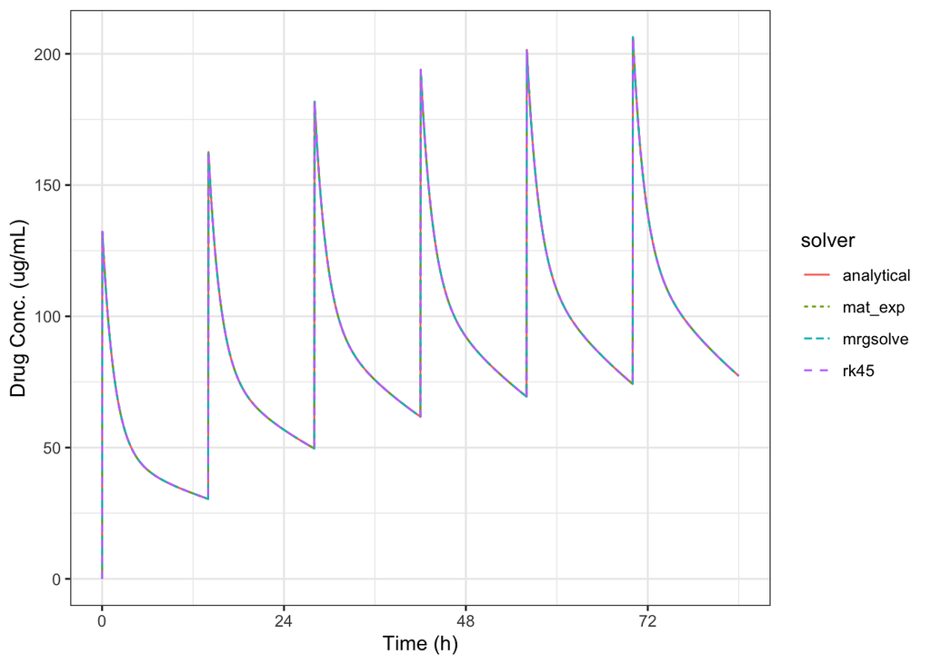

```r
mget(str_subset(ls(), "^data_")) %>%
  bind_rows() %>%
  ggplot(aes(x = TIME, y = IPRED, color = solver)) +
  geom_line(aes(linetype = solver)) +
  theme_bw() +
  scale_x_continuous(name = "Time (h)",
                     breaks = seq(0, 168, by = 24),
                     labels = seq(0, 168, by = 24)) +
  scale_y_continuous(name = "Drug Conc. (ug/mL)")
```

So you can see for the M2, the analytical soultion, linear ODE, general ODE, and mrgsolve simulations are all the same, in contrast with the M3 where the analytical solution was a vector of zeros.

## 2.2 Fitting `pk2cpt`, `pk2cpt_linode`, `pk2cpt_ode` from `example-models/`

I made a few modifications in the R script to fit the project and a couple small changes in the general ODE model while trying to debug it, but no changes of any major substance.

### 2.2.1 `pk2cpt`

```r
model_analytical <- cmdstan_model(
  here::here("M3/example_models_metrum/pk2cpt/pk2cpt.stan"))

fit_analytical <- model_analytical$sample(
  data = here::here("M3/example_models_metrum/pk2cpt/pk2cpt.data.R"),
  init = here::here("M3/example_models_metrum/pk2cpt/pk2cpt.init.R"),
  seed = 3191951,
  chains = 1,
  parallel_chains = 1,
  iter_warmup = 500,
  iter_sampling = 1000,
  adapt_delta = 0.80)
```

```
Running MCMC with 1 chain...

Chain 1 Iteration:    1 / 1500 [  0%]  (Warmup)
```

```
Chain 1 Warning: file '/Users/Arya/R-Projects/torsten_test/M3/example_models_metrum/pk2cpt/pk2cpt.data.R' is being read as an 'RDump' file.
```

```
Chain 1     This format is deprecated and will not receive new features.
```

```
Chain 1     Consider saving your data in JSON format instead.
```

```
Chain 1 Warning: file '/Users/Arya/R-Projects/torsten_test/M3/example_models_metrum/pk2cpt/pk2cpt.init.R' is being read as an 'RDump' file.
```

```
Chain 1     This format is deprecated and will not receive new features.
```

```
Chain 1     Consider saving your data in JSON format instead.
```

```
Chain 1 Informational Message: The current Metropolis proposal is about to be rejected because of the following issue:
```

[output not shown]

```
Chain 1 If this warning occurs sporadically, such as for highly constrained variable types like covariance matrices, then the sampler is fine,
```

```
Chain 1 but if this warning occurs often then your model may be either severely ill-conditioned or misspecified.
```

```
Chain 1
```

```
Chain 1 Informational Message: The current Metropolis proposal is about to be rejected because of the following issue:
```

[output not shown]

```
Chain 1 If this warning occurs sporadically, such as for highly constrained variable types like covariance matrices, then the sampler is fine,
```

```
Chain 1 but if this warning occurs often then your model may be either severely ill-conditioned or misspecified.
```

```
Chain 1
```

```
Chain 1 Informational Message: The current Metropolis proposal is about to be rejected because of the following issue:
```

```
Chain 1 Exception: pk2cpt_model_namespace::log_prob: cHat[1] is nan, but must be greater than or equal to 0.000000 (in '/var/folders/c5/z01xp4bd02j_glk11wknb5jr0000gp/T/Rtmp8pkl24/model-7925944e9cd.stan', line 40, column 2 to column 33)
```

```
Chain 1 If this warning occurs sporadically, such as for highly constrained variable types like covariance matrices, then the sampler is fine,
```

```
Chain 1 but if this warning occurs often then your model may be either severely ill-conditioned or misspecified.
```

```
Chain 1
```

```
Chain 1 Iteration:  100 / 1500 [  6%]  (Warmup)
Chain 1 Iteration:  200 / 1500 [ 13%]  (Warmup)
Chain 1 Iteration:  300 / 1500 [ 20%]  (Warmup)
Chain 1 Iteration:  400 / 1500 [ 26%]  (Warmup)
Chain 1 Iteration:  500 / 1500 [ 33%]  (Warmup)
Chain 1 Iteration:  501 / 1500 [ 33%]  (Sampling)
Chain 1 Iteration:  600 / 1500 [ 40%]  (Sampling)
Chain 1 Iteration:  700 / 1500 [ 46%]  (Sampling)
Chain 1 Iteration:  800 / 1500 [ 53%]  (Sampling)
Chain 1 Iteration:  900 / 1500 [ 60%]  (Sampling)
Chain 1 Iteration: 1000 / 1500 [ 66%]  (Sampling)
Chain 1 Iteration: 1100 / 1500 [ 73%]  (Sampling)
Chain 1 Iteration: 1200 / 1500 [ 80%]  (Sampling)
Chain 1 Iteration: 1300 / 1500 [ 86%]  (Sampling)
Chain 1 Iteration: 1400 / 1500 [ 93%]  (Sampling)
Chain 1 Iteration: 1500 / 1500 [100%]  (Sampling)
Chain 1 finished in 8.0 seconds.
```

This seems to work, in contrast to the M3 where we had a vector of zeros.

### 2.2.2 `pk2cpt_linode`

```r
model_mat_exp <- cmdstan_model(
  here::here("M3/example_models_metrum/pk2cpt_linode/pk2cpt_linode.stan"))
```

[output not shown]

[output not shown]

[output not shown]

```
1 warning generated.
```

```r
fit_mat_exp <- model_mat_exp$sample(
  data = here::here("M3/example_models_metrum/pk2cpt_linode/pk2cpt_linode.data.R"),
  init = here::here("M3/example_models_metrum/pk2cpt_linode/pk2cpt_linode.init.R"),
  seed = 3191951,
  chains = 4,
  parallel_chains = 4,
  iter_warmup = 500,
  iter_sampling = 1000,
  refresh = 0,
  adapt_delta = 0.80)
```

```
Running MCMC with 4 parallel chains...
```

```
Chain 1 Warning: file '/Users/Arya/R-Projects/torsten_test/M3/example_models_metrum/pk2cpt_linode/pk2cpt_linode.data.R' is being read as an 'RDump' file.
```

```
Chain 1     This format is deprecated and will not receive new features.
```

```
Chain 1     Consider saving your data in JSON format instead.
```

```
Chain 1 Warning: file '/Users/Arya/R-Projects/torsten_test/M3/example_models_metrum/pk2cpt_linode/pk2cpt_linode.init.R' is being read as an 'RDump' file.
```

```
Chain 1     This format is deprecated and will not receive new features.
```

```
Chain 1     Consider saving your data in JSON format instead.
```

```
Chain 1 Informational Message: The current Metropolis proposal is about to be rejected because of the following issue:
```

[output not shown]

```
Chain 1 If this warning occurs sporadically, such as for highly constrained variable types like covariance matrices, then the sampler is fine,
```

```
Chain 1 but if this warning occurs often then your model may be either severely ill-conditioned or misspecified.
```

```
Chain 1
```

```
Chain 2 Warning: file '/Users/Arya/R-Projects/torsten_test/M3/example_models_metrum/pk2cpt_linode/pk2cpt_linode.data.R' is being read as an 'RDump' file.
```

```
Chain 2     This format is deprecated and will not receive new features.
```

```
Chain 2     Consider saving your data in JSON format instead.
```

```
Chain 2 Warning: file '/Users/Arya/R-Projects/torsten_test/M3/example_models_metrum/pk2cpt_linode/pk2cpt_linode.init.R' is being read as an 'RDump' file.
```

```
Chain 2     This format is deprecated and will not receive new features.
```

```
Chain 2     Consider saving your data in JSON format instead.
```

```
Chain 2 Informational Message: The current Metropolis proposal is about to be rejected because of the following issue:
```

[output not shown]

```
Chain 2 If this warning occurs sporadically, such as for highly constrained variable types like covariance matrices, then the sampler is fine,
```

```
Chain 2 but if this warning occurs often then your model may be either severely ill-conditioned or misspecified.
```

```
Chain 2
```

```
Chain 2 Informational Message: The current Metropolis proposal is about to be rejected because of the following issue:
```

```
Chain 2 Exception: normal_lpdf: Location parameter[1] is -inf, but must be finite! (in '/var/folders/c5/z01xp4bd02j_glk11wknb5jr0000gp/T/Rtmp8pkl24/model-7921fca1428.stan', line 80, column 2 to column 40)
```

```
Chain 2 If this warning occurs sporadically, such as for highly constrained variable types like covariance matrices, then the sampler is fine,
```

```
Chain 2 but if this warning occurs often then your model may be either severely ill-conditioned or misspecified.
```

```
Chain 2
```

```
Chain 3 Warning: file '/Users/Arya/R-Projects/torsten_test/M3/example_models_metrum/pk2cpt_linode/pk2cpt_linode.data.R' is being read as an 'RDump' file.
```

```
Chain 3     This format is deprecated and will not receive new features.
```

```
Chain 3     Consider saving your data in JSON format instead.
```

```
Chain 3 Warning: file '/Users/Arya/R-Projects/torsten_test/M3/example_models_metrum/pk2cpt_linode/pk2cpt_linode.init.R' is being read as an 'RDump' file.
```

```
Chain 3     This format is deprecated and will not receive new features.
```

```
Chain 3     Consider saving your data in JSON format instead.
```

```
Chain 3 Informational Message: The current Metropolis proposal is about to be rejected because of the following issue:
```

```
Chain 3 Exception: pk2cpt_linode_model_namespace::log_prob: cHat[1] is nan, but must be greater than or equal to 0.000000 (in '/var/folders/c5/z01xp4bd02j_glk11wknb5jr0000gp/T/Rtmp8pkl24/model-7921fca1428.stan', line 49, column 2 to column 33)
```

```
Chain 3 If this warning occurs sporadically, such as for highly constrained variable types like covariance matrices, then the sampler is fine,
```

```
Chain 3 but if this warning occurs often then your model may be either severely ill-conditioned or misspecified.
```

```
Chain 3
```

```
Chain 3 Informational Message: The current Metropolis proposal is about to be rejected because of the following issue:
```

```
Chain 3 Exception: normal_lpdf: Location parameter[1] is -inf, but must be finite! (in '/var/folders/c5/z01xp4bd02j_glk11wknb5jr0000gp/T/Rtmp8pkl24/model-7921fca1428.stan', line 80, column 2 to column 40)
```

```
Chain 3 If this warning occurs sporadically, such as for highly constrained variable types like covariance matrices, then the sampler is fine,
```

```
Chain 3 but if this warning occurs often then your model may be either severely ill-conditioned or misspecified.
```

```
Chain 3
```

```
Chain 4 Warning: file '/Users/Arya/R-Projects/torsten_test/M3/example_models_metrum/pk2cpt_linode/pk2cpt_linode.data.R' is being read as an 'RDump' file.
```

```
Chain 4     This format is deprecated and will not receive new features.
```

```
Chain 4     Consider saving your data in JSON format instead.
```

```
Chain 4 Warning: file '/Users/Arya/R-Projects/torsten_test/M3/example_models_metrum/pk2cpt_linode/pk2cpt_linode.init.R' is being read as an 'RDump' file.
```

```
Chain 4     This format is deprecated and will not receive new features.
```

```
Chain 4     Consider saving your data in JSON format instead.
```

```
Chain 4 Informational Message: The current Metropolis proposal is about to be rejected because of the following issue:
```

```
Chain 4 Exception: pk2cpt_linode_model_namespace::log_prob: cHat[1] is nan, but must be greater than or equal to 0.000000 (in '/var/folders/c5/z01xp4bd02j_glk11wknb5jr0000gp/T/Rtmp8pkl24/model-7921fca1428.stan', line 49, column 2 to column 33)
```

```
Chain 4 If this warning occurs sporadically, such as for highly constrained variable types like covariance matrices, then the sampler is fine,
```

```
Chain 4 but if this warning occurs often then your model may be either severely ill-conditioned or misspecified.
```

```
Chain 4
```

```
Chain 4 finished in 8.8 seconds.
Chain 2 finished in 9.6 seconds.
Chain 3 finished in 10.4 seconds.
Chain 1 finished in 11.0 seconds.

All 4 chains finished successfully.
Mean chain execution time: 10.0 seconds.
Total execution time: 11.2 seconds.
```

Works fine.

### 2.2.3 `pk2cpt_ode`

```r
model_rk45 <- cmdstan_model(
  here::here("M3/example_models_metrum/pk2cpt_ode/pk2cpt_ode.stan"))
```

[output not shown]

[output not shown]

[output not shown]

```
1 warning generated.
```

```r
stan_data_rk45 <- rstan::read_rdump(
  here::here("M3/example_models_metrum/pk2cpt_ode/pk2cpt_ode.data.R"))

stan_data_rk45$prior_only <- 1

fit_rk45 <- model_rk45$sample(
  data = stan_data_rk45,
  init = here::here("M3/example_models_metrum/pk2cpt_ode/pk2cpt_ode.init.R"),
  seed = 3191951,
  chains = 1,
  parallel_chains = 1,
  iter_warmup = 1,
  iter_sampling = 1,
  adapt_delta = 0.80)
```

[output not shown]

```
Chain 1 Warning: file '/Users/Arya/R-Projects/torsten_test/M3/example_models_metrum/pk2cpt_ode/pk2cpt_ode.init.R' is being read as an 'RDump' file.
```

```
Chain 1     This format is deprecated and will not receive new features.
```

```
Chain 1     Consider saving your data in JSON format instead.
```

[output not shown]

```
Chain 1 Informational Message: The current Metropolis proposal is about to be rejected because of the following issue:
```

```
Chain 1 Exception: Max number of iterations exceeded (100000). (in '/var/folders/c5/z01xp4bd02j_glk11wknb5jr0000gp/T/Rtmp8pkl24/model-792260b064d.stan', line 73, column 2 to column 99)
```

```
Chain 1 If this warning occurs sporadically, such as for highly constrained variable types like covariance matrices, then the sampler is fine,
```

```
Chain 1 but if this warning occurs often then your model may be either severely ill-conditioned or misspecified.
```

```
Chain 1
```

```
Chain 1 finished in 0.3 seconds.
```

Works fine, in contrast to the one from the M3, where it was returning a vector of zeros.

## 2.3 Fitting `poppk2cpt` from `example-models/`

I made a couple adjustments in `poppk2cpt.stan` so that it can be fit with an analytical solver, the linear ODE, or the general ODE.

### 2.3.1 Analytical Solution

```r
model <- cmdstan_model(
  here::here("M3/example_models_metrum/poppk2cpt/poppk2cpt.stan"))
```

[output not shown]

[output not shown]

[output not shown]

```
1 warning generated.
```

```r
stan_data <- rstan::read_rdump(
  here::here("M3/example_models_metrum/poppk2cpt/poppk2cpt.data.R"))

stan_data$solver <- 1

fit_analytical <- model$sample(
  data = stan_data,
  init = here::here("M3/example_models_metrum/poppk2cpt/poppk2cpt.init.R"),
  seed = 3191951,
  chains = 4,
  parallel_chains = 4,
  iter_warmup = 500,
  iter_sampling = 500,
  adapt_delta = 0.80)
```

```
Running MCMC with 4 parallel chains...

Chain 1 Iteration:   1 / 1000 [  0%]  (Warmup)
```

```
Chain 1 Warning: file '/Users/Arya/R-Projects/torsten_test/M3/example_models_metrum/poppk2cpt/poppk2cpt.init.R' is being read as an 'RDump' file.
```

```
Chain 1     This format is deprecated and will not receive new features.
```

```
Chain 1     Consider saving your data in JSON format instead.
```

```
Chain 1 Informational Message: The current Metropolis proposal is about to be rejected because of the following issue:
```

[output not shown]

```
Chain 1 If this warning occurs sporadically, such as for highly constrained variable types like covariance matrices, then the sampler is fine,
```

```
Chain 1 but if this warning occurs often then your model may be either severely ill-conditioned or misspecified.
```

```
Chain 1
```

```
Chain 1 Informational Message: The current Metropolis proposal is about to be rejected because of the following issue:
```

```
Chain 1 Exception: poppk2cpt_model_namespace::log_prob: x[1, 1] is nan, but must be greater than or equal to 0.000000 (in '/var/folders/c5/z01xp4bd02j_glk11wknb5jr0000gp/T/Rtmp8pkl24/model-79276bf128.stan', line 83, column 2 to column 32)
```

```
Chain 1 If this warning occurs sporadically, such as for highly constrained variable types like covariance matrices, then the sampler is fine,
```

```
Chain 1 but if this warning occurs often then your model may be either severely ill-conditioned or misspecified.
```

```
Chain 1
```

```
Chain 1 Informational Message: The current Metropolis proposal is about to be rejected because of the following issue:
```

[output not shown]

```
Chain 1 If this warning occurs sporadically, such as for highly constrained variable types like covariance matrices, then the sampler is fine,
```

```
Chain 1 but if this warning occurs often then your model may be either severely ill-conditioned or misspecified.
```

```
Chain 1
```

```
Chain 1 Informational Message: The current Metropolis proposal is about to be rejected because of the following issue:
```

```
Chain 1 Exception: poppk2cpt_model_namespace::log_prob: x[1, 1] is nan, but must be greater than or equal to 0.000000 (in '/var/folders/c5/z01xp4bd02j_glk11wknb5jr0000gp/T/Rtmp8pkl24/model-79276bf128.stan', line 83, column 2 to column 32)
```

```
Chain 1 If this warning occurs sporadically, such as for highly constrained variable types like covariance matrices, then the sampler is fine,
```

```
Chain 1 but if this warning occurs often then your model may be either severely ill-conditioned or misspecified.
```

```
Chain 1
```

```
Chain 2 Iteration:   1 / 1000 [  0%]  (Warmup)
```

```
Chain 2 Warning: file '/Users/Arya/R-Projects/torsten_test/M3/example_models_metrum/poppk2cpt/poppk2cpt.init.R' is being read as an 'RDump' file.
```

```
Chain 2     This format is deprecated and will not receive new features.
```

```
Chain 2     Consider saving your data in JSON format instead.
```

```
Chain 2 Informational Message: The current Metropolis proposal is about to be rejected because of the following issue:
```

```
Chain 2 Exception: poppk2cpt_model_namespace::log_prob: x[1, 1] is nan, but must be greater than or equal to 0.000000 (in '/var/folders/c5/z01xp4bd02j_glk11wknb5jr0000gp/T/Rtmp8pkl24/model-79276bf128.stan', line 83, column 2 to column 32)
```

```
Chain 2 If this warning occurs sporadically, such as for highly constrained variable types like covariance matrices, then the sampler is fine,
```

```
Chain 2 but if this warning occurs often then your model may be either severely ill-conditioned or misspecified.
```

```
Chain 2
```

```
Chain 2 Informational Message: The current Metropolis proposal is about to be rejected because of the following issue:
```

```
Chain 2 Exception: poppk2cpt_model_namespace::log_prob: x[1, 1] is nan, but must be greater than or equal to 0.000000 (in '/var/folders/c5/z01xp4bd02j_glk11wknb5jr0000gp/T/Rtmp8pkl24/model-79276bf128.stan', line 83, column 2 to column 32)
```

```
Chain 2 If this warning occurs sporadically, such as for highly constrained variable types like covariance matrices, then the sampler is fine,
```

```
Chain 2 but if this warning occurs often then your model may be either severely ill-conditioned or misspecified.
```

```
Chain 2
```

```
Chain 2 Informational Message: The current Metropolis proposal is about to be rejected because of the following issue:
```

```
Chain 2 Exception: PMXTwoCptModel: Q is 0, but must be positive finite! (in '/var/folders/c5/z01xp4bd02j_glk11wknb5jr0000gp/T/Rtmp8pkl24/model-79276bf128.stan', line 106, column 6 to line 114, column 67)
```

```
Chain 2 If this warning occurs sporadically, such as for highly constrained variable types like covariance matrices, then the sampler is fine,
```

```
Chain 2 but if this warning occurs often then your model may be either severely ill-conditioned or misspecified.
```

```
Chain 2
```

```
Chain 2 Informational Message: The current Metropolis proposal is about to be rejected because of the following issue:
```

[output not shown]

```
Chain 2 If this warning occurs sporadically, such as for highly constrained variable types like covariance matrices, then the sampler is fine,
```

```
Chain 2 but if this warning occurs often then your model may be either severely ill-conditioned or misspecified.
```

```
Chain 2
```

```
Chain 3 Iteration:   1 / 1000 [  0%]  (Warmup)
```

```
Chain 3 Warning: file '/Users/Arya/R-Projects/torsten_test/M3/example_models_metrum/poppk2cpt/poppk2cpt.init.R' is being read as an 'RDump' file.
```

```
Chain 3     This format is deprecated and will not receive new features.
```

```
Chain 3     Consider saving your data in JSON format instead.
```

```
Chain 3 Informational Message: The current Metropolis proposal is about to be rejected because of the following issue:
```

```
Chain 3 Exception: poppk2cpt_model_namespace::log_prob: x[1, 1] is nan, but must be greater than or equal to 0.000000 (in '/var/folders/c5/z01xp4bd02j_glk11wknb5jr0000gp/T/Rtmp8pkl24/model-79276bf128.stan', line 83, column 2 to column 32)
```

```
Chain 3 If this warning occurs sporadically, such as for highly constrained variable types like covariance matrices, then the sampler is fine,
```

```
Chain 3 but if this warning occurs often then your model may be either severely ill-conditioned or misspecified.
```

```
Chain 3
```

```
Chain 3 Informational Message: The current Metropolis proposal is about to be rejected because of the following issue:
```

```
Chain 3 Exception: poppk2cpt_model_namespace::log_prob: x[1, 1] is nan, but must be greater than or equal to 0.000000 (in '/var/folders/c5/z01xp4bd02j_glk11wknb5jr0000gp/T/Rtmp8pkl24/model-79276bf128.stan', line 83, column 2 to column 32)
```

```
Chain 3 If this warning occurs sporadically, such as for highly constrained variable types like covariance matrices, then the sampler is fine,
```

```
Chain 3 but if this warning occurs often then your model may be either severely ill-conditioned or misspecified.
```

```
Chain 3
```

```
Chain 3 Informational Message: The current Metropolis proposal is about to be rejected because of the following issue:
```

```
Chain 3 Exception: PMXTwoCptModel: Q is 0, but must be positive finite! (in '/var/folders/c5/z01xp4bd02j_glk11wknb5jr0000gp/T/Rtmp8pkl24/model-79276bf128.stan', line 106, column 6 to line 114, column 67)
```

```
Chain 3 If this warning occurs sporadically, such as for highly constrained variable types like covariance matrices, then the sampler is fine,
```

```
Chain 3 but if this warning occurs often then your model may be either severely ill-conditioned or misspecified.
```

```
Chain 3
```

```
Chain 3 Informational Message: The current Metropolis proposal is about to be rejected because of the following issue:
```

```
Chain 3 Exception: poppk2cpt_model_namespace::log_prob: x[1, 1] is nan, but must be greater than or equal to 0.000000 (in '/var/folders/c5/z01xp4bd02j_glk11wknb5jr0000gp/T/Rtmp8pkl24/model-79276bf128.stan', line 83, column 2 to column 32)
```

```
Chain 3 If this warning occurs sporadically, such as for highly constrained variable types like covariance matrices, then the sampler is fine,
```

```
Chain 3 but if this warning occurs often then your model may be either severely ill-conditioned or misspecified.
```

```
Chain 3
```

```
Chain 4 Iteration:   1 / 1000 [  0%]  (Warmup)
```

```
Chain 4 Warning: file '/Users/Arya/R-Projects/torsten_test/M3/example_models_metrum/poppk2cpt/poppk2cpt.init.R' is being read as an 'RDump' file.
```

```
Chain 4     This format is deprecated and will not receive new features.
```

```
Chain 4     Consider saving your data in JSON format instead.
```

```
Chain 4 Informational Message: The current Metropolis proposal is about to be rejected because of the following issue:
```

```
Chain 4 Exception: poppk2cpt_model_namespace::log_prob: x[1, 1] is nan, but must be greater than or equal to 0.000000 (in '/var/folders/c5/z01xp4bd02j_glk11wknb5jr0000gp/T/Rtmp8pkl24/model-79276bf128.stan', line 83, column 2 to column 32)
```

```
Chain 4 If this warning occurs sporadically, such as for highly constrained variable types like covariance matrices, then the sampler is fine,
```

```
Chain 4 but if this warning occurs often then your model may be either severely ill-conditioned or misspecified.
```

```
Chain 4
```

```
Chain 4 Informational Message: The current Metropolis proposal is about to be rejected because of the following issue:
```

```
Chain 4 Exception: poppk2cpt_model_namespace::log_prob: x[1, 1] is nan, but must be greater than or equal to 0.000000 (in '/var/folders/c5/z01xp4bd02j_glk11wknb5jr0000gp/T/Rtmp8pkl24/model-79276bf128.stan', line 83, column 2 to column 32)
```

```
Chain 4 If this warning occurs sporadically, such as for highly constrained variable types like covariance matrices, then the sampler is fine,
```

```
Chain 4 but if this warning occurs often then your model may be either severely ill-conditioned or misspecified.
```

```
Chain 4
```

```
Chain 4 Informational Message: The current Metropolis proposal is about to be rejected because of the following issue:
```

```
Chain 4 Exception: PMXTwoCptModel: CL is 0, but must be positive finite! (in '/var/folders/c5/z01xp4bd02j_glk11wknb5jr0000gp/T/Rtmp8pkl24/model-79276bf128.stan', line 106, column 6 to line 114, column 67)
```

```
Chain 4 If this warning occurs sporadically, such as for highly constrained variable types like covariance matrices, then the sampler is fine,
```

```
Chain 4 but if this warning occurs often then your model may be either severely ill-conditioned or misspecified.
```

```
Chain 4
```

```
Chain 4 Informational Message: The current Metropolis proposal is about to be rejected because of the following issue:
```

```
Chain 4 Exception: poppk2cpt_model_namespace::log_prob: x[1, 1] is nan, but must be greater than or equal to 0.000000 (in '/var/folders/c5/z01xp4bd02j_glk11wknb5jr0000gp/T/Rtmp8pkl24/model-79276bf128.stan', line 83, column 2 to column 32)
```

```
Chain 4 If this warning occurs sporadically, such as for highly constrained variable types like covariance matrices, then the sampler is fine,
```

```
Chain 4 but if this warning occurs often then your model may be either severely ill-conditioned or misspecified.
```

```
Chain 4
```

```
Chain 4 Iteration: 100 / 1000 [ 10%]  (Warmup)
Chain 2 Iteration: 100 / 1000 [ 10%]  (Warmup)
Chain 3 Iteration: 100 / 1000 [ 10%]  (Warmup)
Chain 1 Iteration: 100 / 1000 [ 10%]  (Warmup)
Chain 2 Iteration: 200 / 1000 [ 20%]  (Warmup)
Chain 3 Iteration: 200 / 1000 [ 20%]  (Warmup)
Chain 4 Iteration: 200 / 1000 [ 20%]  (Warmup)
Chain 1 Iteration: 200 / 1000 [ 20%]  (Warmup)
Chain 2 Iteration: 300 / 1000 [ 30%]  (Warmup)
Chain 3 Iteration: 300 / 1000 [ 30%]  (Warmup)
Chain 4 Iteration: 300 / 1000 [ 30%]  (Warmup)
Chain 1 Iteration: 300 / 1000 [ 30%]  (Warmup)
Chain 2 Iteration: 400 / 1000 [ 40%]  (Warmup)
Chain 3 Iteration: 400 / 1000 [ 40%]  (Warmup)
Chain 4 Iteration: 400 / 1000 [ 40%]  (Warmup)
Chain 1 Iteration: 400 / 1000 [ 40%]  (Warmup)
Chain 2 Iteration: 500 / 1000 [ 50%]  (Warmup)
Chain 2 Iteration: 501 / 1000 [ 50%]  (Sampling)
Chain 4 Iteration: 500 / 1000 [ 50%]  (Warmup)
Chain 4 Iteration: 501 / 1000 [ 50%]  (Sampling)
Chain 3 Iteration: 500 / 1000 [ 50%]  (Warmup)
Chain 3 Iteration: 501 / 1000 [ 50%]  (Sampling)
Chain 1 Iteration: 500 / 1000 [ 50%]  (Warmup)
Chain 1 Iteration: 501 / 1000 [ 50%]  (Sampling)
Chain 2 Iteration: 600 / 1000 [ 60%]  (Sampling)
Chain 4 Iteration: 600 / 1000 [ 60%]  (Sampling)
Chain 3 Iteration: 600 / 1000 [ 60%]  (Sampling)
Chain 1 Iteration: 600 / 1000 [ 60%]  (Sampling)
Chain 2 Iteration: 700 / 1000 [ 70%]  (Sampling)
Chain 4 Iteration: 700 / 1000 [ 70%]  (Sampling)
Chain 3 Iteration: 700 / 1000 [ 70%]  (Sampling)
Chain 1 Iteration: 700 / 1000 [ 70%]  (Sampling)
Chain 2 Iteration: 800 / 1000 [ 80%]  (Sampling)
Chain 4 Iteration: 800 / 1000 [ 80%]  (Sampling)
Chain 3 Iteration: 800 / 1000 [ 80%]  (Sampling)
Chain 1 Iteration: 800 / 1000 [ 80%]  (Sampling)
Chain 2 Iteration: 900 / 1000 [ 90%]  (Sampling)
Chain 4 Iteration: 900 / 1000 [ 90%]  (Sampling)
Chain 1 Iteration: 900 / 1000 [ 90%]  (Sampling)
Chain 3 Iteration: 900 / 1000 [ 90%]  (Sampling)
Chain 2 Iteration: 1000 / 1000 [100%]  (Sampling)
Chain 2 finished in 226.7 seconds.
Chain 4 Iteration: 1000 / 1000 [100%]  (Sampling)
Chain 4 finished in 231.2 seconds.
Chain 1 Iteration: 1000 / 1000 [100%]  (Sampling)
Chain 1 finished in 232.0 seconds.
Chain 3 Iteration: 1000 / 1000 [100%]  (Sampling)
Chain 3 finished in 232.9 seconds.

All 4 chains finished successfully.
Mean chain execution time: 230.7 seconds.
Total execution time: 233.0 seconds.
```

This one fits fine.

### 2.3.2 Linear ODE Solution

```r
stan_data$solver <- 2

fit_mat_exp <- model$sample(
  data = stan_data,
  init = here::here("M3/example_models_metrum/poppk2cpt/poppk2cpt.init.R"),
  seed = 3191951,
  chains = 4,
  parallel_chains = 4,
  iter_warmup = 300,
  iter_sampling = 100,
  adapt_delta = 0.80)
```

```
Running MCMC with 4 parallel chains...
```

```
Chain 1 Warning: file '/Users/Arya/R-Projects/torsten_test/M3/example_models_metrum/poppk2cpt/poppk2cpt.init.R' is being read as an 'RDump' file.
```

```
Chain 1     This format is deprecated and will not receive new features.
```

```
Chain 1     Consider saving your data in JSON format instead.
```

```
Chain 2 Warning: file '/Users/Arya/R-Projects/torsten_test/M3/example_models_metrum/poppk2cpt/poppk2cpt.init.R' is being read as an 'RDump' file.
```

```
Chain 2     This format is deprecated and will not receive new features.
```

```
Chain 2     Consider saving your data in JSON format instead.
```

```
Chain 3 Warning: file '/Users/Arya/R-Projects/torsten_test/M3/example_models_metrum/poppk2cpt/poppk2cpt.init.R' is being read as an 'RDump' file.
```

```
Chain 3     This format is deprecated and will not receive new features.
```

```
Chain 3     Consider saving your data in JSON format instead.
```

```
Chain 4 Warning: file '/Users/Arya/R-Projects/torsten_test/M3/example_models_metrum/poppk2cpt/poppk2cpt.init.R' is being read as an 'RDump' file.
```

```
Chain 4     This format is deprecated and will not receive new features.
```

```
Chain 4     Consider saving your data in JSON format instead.
```

```
Chain 1 Iteration:   1 / 400 [  0%]  (Warmup)
```

```
Chain 1 Informational Message: The current Metropolis proposal is about to be rejected because of the following issue:
```

[output not shown]

```
Chain 1 If this warning occurs sporadically, such as for highly constrained variable types like covariance matrices, then the sampler is fine,
```

```
Chain 1 but if this warning occurs often then your model may be either severely ill-conditioned or misspecified.
```

```
Chain 1
```

```
Chain 1 Informational Message: The current Metropolis proposal is about to be rejected because of the following issue:
```

```
Chain 1 Exception: normal_lpdf: Location parameter[1] is -inf, but must be finite! (in '/var/folders/c5/z01xp4bd02j_glk11wknb5jr0000gp/T/Rtmp8pkl24/model-79276bf128.stan', line 176, column 2 to column 40)
```

```
Chain 1 If this warning occurs sporadically, such as for highly constrained variable types like covariance matrices, then the sampler is fine,
```

```
Chain 1 but if this warning occurs often then your model may be either severely ill-conditioned or misspecified.
```

```
Chain 1
```

```
Chain 2 Informational Message: The current Metropolis proposal is about to be rejected because of the following issue:
```

```
Chain 2 Exception: normal_lpdf: Location parameter[1] is -inf, but must be finite! (in '/var/folders/c5/z01xp4bd02j_glk11wknb5jr0000gp/T/Rtmp8pkl24/model-79276bf128.stan', line 176, column 2 to column 40)
```

```
Chain 2 If this warning occurs sporadically, such as for highly constrained variable types like covariance matrices, then the sampler is fine,
```

```
Chain 2 but if this warning occurs often then your model may be either severely ill-conditioned or misspecified.
```

```
Chain 2
```

```
Chain 2 Informational Message: The current Metropolis proposal is about to be rejected because of the following issue:
```

```
Chain 2 Exception: normal_lpdf: Location parameter[1] is -inf, but must be finite! (in '/var/folders/c5/z01xp4bd02j_glk11wknb5jr0000gp/T/Rtmp8pkl24/model-79276bf128.stan', line 176, column 2 to column 40)
```

```
Chain 2 If this warning occurs sporadically, such as for highly constrained variable types like covariance matrices, then the sampler is fine,
```

```
Chain 2 but if this warning occurs often then your model may be either severely ill-conditioned or misspecified.
```

```
Chain 2
```

```
Chain 2 Informational Message: The current Metropolis proposal is about to be rejected because of the following issue:
```

[output not shown]

```
Chain 2 If this warning occurs sporadically, such as for highly constrained variable types like covariance matrices, then the sampler is fine,
```

```
Chain 2 but if this warning occurs often then your model may be either severely ill-conditioned or misspecified.
```

```
Chain 2
```

```
Chain 3 Iteration:   1 / 400 [  0%]  (Warmup)
```

```
Chain 3 Informational Message: The current Metropolis proposal is about to be rejected because of the following issue:
```

```
Chain 3 Exception: normal_lpdf: Location parameter[1] is -inf, but must be finite! (in '/var/folders/c5/z01xp4bd02j_glk11wknb5jr0000gp/T/Rtmp8pkl24/model-79276bf128.stan', line 176, column 2 to column 40)
```

```
Chain 3 If this warning occurs sporadically, such as for highly constrained variable types like covariance matrices, then the sampler is fine,
```

```
Chain 3 but if this warning occurs often then your model may be either severely ill-conditioned or misspecified.
```

```
Chain 3
```

```
Chain 3 Informational Message: The current Metropolis proposal is about to be rejected because of the following issue:
```

```
Chain 3 Exception: normal_lpdf: Location parameter[1] is -inf, but must be finite! (in '/var/folders/c5/z01xp4bd02j_glk11wknb5jr0000gp/T/Rtmp8pkl24/model-79276bf128.stan', line 176, column 2 to column 40)
```

```
Chain 3 If this warning occurs sporadically, such as for highly constrained variable types like covariance matrices, then the sampler is fine,
```

```
Chain 3 but if this warning occurs often then your model may be either severely ill-conditioned or misspecified.
```

```
Chain 3
```

```
Chain 4 Informational Message: The current Metropolis proposal is about to be rejected because of the following issue:
```

```
Chain 4 Exception: normal_lpdf: Location parameter[1] is -inf, but must be finite! (in '/var/folders/c5/z01xp4bd02j_glk11wknb5jr0000gp/T/Rtmp8pkl24/model-79276bf128.stan', line 176, column 2 to column 40)
```

```
Chain 4 If this warning occurs sporadically, such as for highly constrained variable types like covariance matrices, then the sampler is fine,
```

```
Chain 4 but if this warning occurs often then your model may be either severely ill-conditioned or misspecified.
```

```
Chain 4
```

```
Chain 4 Informational Message: The current Metropolis proposal is about to be rejected because of the following issue:
```

```
Chain 4 Exception: normal_lpdf: Location parameter[1] is -inf, but must be finite! (in '/var/folders/c5/z01xp4bd02j_glk11wknb5jr0000gp/T/Rtmp8pkl24/model-79276bf128.stan', line 176, column 2 to column 40)
```

```
Chain 4 If this warning occurs sporadically, such as for highly constrained variable types like covariance matrices, then the sampler is fine,
```

```
Chain 4 but if this warning occurs often then your model may be either severely ill-conditioned or misspecified.
```

```
Chain 4
```

```
Chain 4 Informational Message: The current Metropolis proposal is about to be rejected because of the following issue:
```

```
Chain 4 Exception: poppk2cpt_model_namespace::log_prob: x[1, 82] is -7.37449e-13, but must be greater than or equal to 0.000000 (in '/var/folders/c5/z01xp4bd02j_glk11wknb5jr0000gp/T/Rtmp8pkl24/model-79276bf128.stan', line 83, column 2 to column 32)
```

```
Chain 4 If this warning occurs sporadically, such as for highly constrained variable types like covariance matrices, then the sampler is fine,
```

```
Chain 4 but if this warning occurs often then your model may be either severely ill-conditioned or misspecified.
```

```
Chain 4
```

```
Chain 1 Informational Message: The current Metropolis proposal is about to be rejected because of the following issue:
```

```
Chain 1 Exception: poppk2cpt_model_namespace::log_prob: x[1, 1] is nan, but must be greater than or equal to 0.000000 (in '/var/folders/c5/z01xp4bd02j_glk11wknb5jr0000gp/T/Rtmp8pkl24/model-79276bf128.stan', line 83, column 2 to column 32)
```

```
Chain 1 If this warning occurs sporadically, such as for highly constrained variable types like covariance matrices, then the sampler is fine,
```

```
Chain 1 but if this warning occurs often then your model may be either severely ill-conditioned or misspecified.
```

```
Chain 1
```

```
Chain 2 Iteration:   1 / 400 [  0%]  (Warmup)
```

```
Chain 3 Informational Message: The current Metropolis proposal is about to be rejected because of the following issue:
```

```
Chain 3 Exception: poppk2cpt_model_namespace::log_prob: thetaM[1, 3] is nan, but must be greater than or equal to 0.000000 (in '/var/folders/c5/z01xp4bd02j_glk11wknb5jr0000gp/T/Rtmp8pkl24/model-79276bf128.stan', line 81, column 2 to column 44)
```

```
Chain 3 If this warning occurs sporadically, such as for highly constrained variable types like covariance matrices, then the sampler is fine,
```

```
Chain 3 but if this warning occurs often then your model may be either severely ill-conditioned or misspecified.
```

```
Chain 3
```

```
Chain 3 Informational Message: The current Metropolis proposal is about to be rejected because of the following issue:
```

```
Chain 3 Exception: normal_lpdf: Location parameter[1] is -inf, but must be finite! (in '/var/folders/c5/z01xp4bd02j_glk11wknb5jr0000gp/T/Rtmp8pkl24/model-79276bf128.stan', line 176, column 2 to column 40)
```

```
Chain 3 If this warning occurs sporadically, such as for highly constrained variable types like covariance matrices, then the sampler is fine,
```

```
Chain 3 but if this warning occurs often then your model may be either severely ill-conditioned or misspecified.
```

```
Chain 3
```

```
Chain 4 Iteration:   1 / 400 [  0%]  (Warmup)
```

```
Chain 4 Informational Message: The current Metropolis proposal is about to be rejected because of the following issue:
```

```
Chain 4 Exception: poppk2cpt_model_namespace::log_prob: x[1, 1] is nan, but must be greater than or equal to 0.000000 (in '/var/folders/c5/z01xp4bd02j_glk11wknb5jr0000gp/T/Rtmp8pkl24/model-79276bf128.stan', line 83, column 2 to column 32)
```

[output not shown]

```
Chain 4 but if this warning occurs often then your model may be either severely ill-conditioned or misspecified.
```

```
Chain 4
```

```
Chain 1 Informational Message: The current Metropolis proposal is about to be rejected because of the following issue:
```

```
Chain 1 Exception: normal_lpdf: Location parameter[1] is -inf, but must be finite! (in '/var/folders/c5/z01xp4bd02j_glk11wknb5jr0000gp/T/Rtmp8pkl24/model-79276bf128.stan', line 176, column 2 to column 40)
```

```
Chain 1 If this warning occurs sporadically, such as for highly constrained variable types like covariance matrices, then the sampler is fine,
```

```
Chain 1 but if this warning occurs often then your model may be either severely ill-conditioned or misspecified.
```

```
Chain 1
```

```
Chain 2 Informational Message: The current Metropolis proposal is about to be rejected because of the following issue:
```

```
Chain 2 Exception: normal_lpdf: Location parameter[1] is -inf, but must be finite! (in '/var/folders/c5/z01xp4bd02j_glk11wknb5jr0000gp/T/Rtmp8pkl24/model-79276bf128.stan', line 176, column 2 to column 40)
```

```
Chain 2 If this warning occurs sporadically, such as for highly constrained variable types like covariance matrices, then the sampler is fine,
```

```
Chain 2 but if this warning occurs often then your model may be either severely ill-conditioned or misspecified.
```

```
Chain 2
```

```
Chain 2 Informational Message: The current Metropolis proposal is about to be rejected because of the following issue:
```

[output not shown]

```
Chain 2 If this warning occurs sporadically, such as for highly constrained variable types like covariance matrices, then the sampler is fine,
```

```
Chain 2 but if this warning occurs often then your model may be either severely ill-conditioned or misspecified.
```

```
Chain 2
```

```
Chain 2 Informational Message: The current Metropolis proposal is about to be rejected because of the following issue:
```

[output not shown]

```
Chain 2 If this warning occurs sporadically, such as for highly constrained variable types like covariance matrices, then the sampler is fine,
```

```
Chain 2 but if this warning occurs often then your model may be either severely ill-conditioned or misspecified.
```

```
Chain 2
```

```
Chain 2 Informational Message: The current Metropolis proposal is about to be rejected because of the following issue:
```

[output not shown]

```
Chain 2 If this warning occurs sporadically, such as for highly constrained variable types like covariance matrices, then the sampler is fine,
```

```
Chain 2 but if this warning occurs often then your model may be either severely ill-conditioned or misspecified.
```

```
Chain 2
```

```
Chain 2 Informational Message: The current Metropolis proposal is about to be rejected because of the following issue:
```

[output not shown]

```
Chain 2 If this warning occurs sporadically, such as for highly constrained variable types like covariance matrices, then the sampler is fine,
```

```
Chain 2 but if this warning occurs often then your model may be either severely ill-conditioned or misspecified.
```

```
Chain 2
```

```
Chain 2 Informational Message: The current Metropolis proposal is about to be rejected because of the following issue:
```

[output not shown]

```
Chain 2 If this warning occurs sporadically, such as for highly constrained variable types like covariance matrices, then the sampler is fine,
```

```
Chain 2 but if this warning occurs often then your model may be either severely ill-conditioned or misspecified.
```

```
Chain 2
```

```
Chain 2 Informational Message: The current Metropolis proposal is about to be rejected because of the following issue:
```

[output not shown]

```
Chain 2 If this warning occurs sporadically, such as for highly constrained variable types like covariance matrices, then the sampler is fine,
```

```
Chain 2 but if this warning occurs often then your model may be either severely ill-conditioned or misspecified.
```

```
Chain 2
```

```
Chain 2 Informational Message: The current Metropolis proposal is about to be rejected because of the following issue:
```

[output not shown]

```
Chain 2 If this warning occurs sporadically, such as for highly constrained variable types like covariance matrices, then the sampler is fine,
```

```
Chain 2 but if this warning occurs often then your model may be either severely ill-conditioned or misspecified.
```

```
Chain 2
```

```
Chain 2 Informational Message: The current Metropolis proposal is about to be rejected because of the following issue:
```

[output not shown]

```
Chain 2 If this warning occurs sporadically, such as for highly constrained variable types like covariance matrices, then the sampler is fine,
```

```
Chain 2 but if this warning occurs often then your model may be either severely ill-conditioned or misspecified.
```

```
Chain 2
```

```
Chain 2 Informational Message: The current Metropolis proposal is about to be rejected because of the following issue:
```

[output not shown]

```
Chain 2 If this warning occurs sporadically, such as for highly constrained variable types like covariance matrices, then the sampler is fine,
```

```
Chain 2 but if this warning occurs often then your model may be either severely ill-conditioned or misspecified.
```

```
Chain 2
```

```
Chain 4 Informational Message: The current Metropolis proposal is about to be rejected because of the following issue:
```

```
Chain 4 Exception: normal_lpdf: Location parameter[1] is -inf, but must be finite! (in '/var/folders/c5/z01xp4bd02j_glk11wknb5jr0000gp/T/Rtmp8pkl24/model-79276bf128.stan', line 176, column 2 to column 40)
```

```
Chain 4 If this warning occurs sporadically, such as for highly constrained variable types like covariance matrices, then the sampler is fine,
```

```
Chain 4 but if this warning occurs often then your model may be either severely ill-conditioned or misspecified.
```

```
Chain 4
```

```
Chain 2 Informational Message: The current Metropolis proposal is about to be rejected because of the following issue:
```

[output not shown]

```
Chain 2 If this warning occurs sporadically, such as for highly constrained variable types like covariance matrices, then the sampler is fine,
```

```
Chain 2 but if this warning occurs often then your model may be either severely ill-conditioned or misspecified.
```

```
Chain 2
```

```
Chain 2 Informational Message: The current Metropolis proposal is about to be rejected because of the following issue:
```

[output not shown]

```
Chain 2 If this warning occurs sporadically, such as for highly constrained variable types like covariance matrices, then the sampler is fine,
```

```
Chain 2 but if this warning occurs often then your model may be either severely ill-conditioned or misspecified.
```

```
Chain 2
```

```
Chain 2 Informational Message: The current Metropolis proposal is about to be rejected because of the following issue:
```

[output not shown]

```
Chain 2 If this warning occurs sporadically, such as for highly constrained variable types like covariance matrices, then the sampler is fine,
```

```
Chain 2 but if this warning occurs often then your model may be either severely ill-conditioned or misspecified.
```

```
Chain 2
```

```
Chain 2 Informational Message: The current Metropolis proposal is about to be rejected because of the following issue:
```

[output not shown]

```
Chain 2 If this warning occurs sporadically, such as for highly constrained variable types like covariance matrices, then the sampler is fine,
```

```
Chain 2 but if this warning occurs often then your model may be either severely ill-conditioned or misspecified.
```

```
Chain 2
```

```
Chain 2 Informational Message: The current Metropolis proposal is about to be rejected because of the following issue:
```

[output not shown]

```
Chain 2 If this warning occurs sporadically, such as for highly constrained variable types like covariance matrices, then the sampler is fine,
```

```
Chain 2 but if this warning occurs often then your model may be either severely ill-conditioned or misspecified.
```

```
Chain 2
```

```
Chain 2 Informational Message: The current Metropolis proposal is about to be rejected because of the following issue:
```

[output not shown]

```
Chain 2 If this warning occurs sporadically, such as for highly constrained variable types like covariance matrices, then the sampler is fine,
```

```
Chain 2 but if this warning occurs often then your model may be either severely ill-conditioned or misspecified.
```

```
Chain 2
```

```
Chain 2 Informational Message: The current Metropolis proposal is about to be rejected because of the following issue:
```

[output not shown]

```
Chain 2 If this warning occurs sporadically, such as for highly constrained variable types like covariance matrices, then the sampler is fine,
```

```
Chain 2 but if this warning occurs often then your model may be either severely ill-conditioned or misspecified.
```

```
Chain 2
```

```
Chain 2 Informational Message: The current Metropolis proposal is about to be rejected because of the following issue:
```

[output not shown]

```
Chain 2 If this warning occurs sporadically, such as for highly constrained variable types like covariance matrices, then the sampler is fine,
```

```
Chain 2 but if this warning occurs often then your model may be either severely ill-conditioned or misspecified.
```

```
Chain 2
```

```
Chain 2 Informational Message: The current Metropolis proposal is about to be rejected because of the following issue:
```

[output not shown]

```
Chain 2 If this warning occurs sporadically, such as for highly constrained variable types like covariance matrices, then the sampler is fine,
```

```
Chain 2 but if this warning occurs often then your model may be either severely ill-conditioned or misspecified.
```

```
Chain 2
```

```
Chain 2 Informational Message: The current Metropolis proposal is about to be rejected because of the following issue:
```

[output not shown]

```
Chain 2 If this warning occurs sporadically, such as for highly constrained variable types like covariance matrices, then the sampler is fine,
```

```
Chain 2 but if this warning occurs often then your model may be either severely ill-conditioned or misspecified.
```

```
Chain 2
```

```
Chain 2 Informational Message: The current Metropolis proposal is about to be rejected because of the following issue:
```

[output not shown]

```
Chain 2 If this warning occurs sporadically, such as for highly constrained variable types like covariance matrices, then the sampler is fine,
```

```
Chain 2 but if this warning occurs often then your model may be either severely ill-conditioned or misspecified.
```

```
Chain 2
```

```
Chain 2 Informational Message: The current Metropolis proposal is about to be rejected because of the following issue:
```

[output not shown]

```
Chain 2 If this warning occurs sporadically, such as for highly constrained variable types like covariance matrices, then the sampler is fine,
```

```
Chain 2 but if this warning occurs often then your model may be either severely ill-conditioned or misspecified.
```

```
Chain 2
```

```
Chain 2 Informational Message: The current Metropolis proposal is about to be rejected because of the following issue:
```

[output not shown]

```
Chain 2 If this warning occurs sporadically, such as for highly constrained variable types like covariance matrices, then the sampler is fine,
```

```
Chain 2 but if this warning occurs often then your model may be either severely ill-conditioned or misspecified.
```

```
Chain 2
```

```
Chain 2 Informational Message: The current Metropolis proposal is about to be rejected because of the following issue:
```

[output not shown]

```
Chain 2 If this warning occurs sporadically, such as for highly constrained variable types like covariance matrices, then the sampler is fine,
```

```
Chain 2 but if this warning occurs often then your model may be either severely ill-conditioned or misspecified.
```

```
Chain 2
```

```
Chain 2 Informational Message: The current Metropolis proposal is about to be rejected because of the following issue:
```

[output not shown]

```
Chain 2 If this warning occurs sporadically, such as for highly constrained variable types like covariance matrices, then the sampler is fine,
```

```
Chain 2 but if this warning occurs often then your model may be either severely ill-conditioned or misspecified.
```

```
Chain 2
```

```
Chain 2 Informational Message: The current Metropolis proposal is about to be rejected because of the following issue:
```

[output not shown]

```
Chain 2 If this warning occurs sporadically, such as for highly constrained variable types like covariance matrices, then the sampler is fine,
```

```
Chain 2 but if this warning occurs often then your model may be either severely ill-conditioned or misspecified.
```

```
Chain 2
```

```
Chain 2 Informational Message: The current Metropolis proposal is about to be rejected because of the following issue:
```

[output not shown]

```
Chain 2 If this warning occurs sporadically, such as for highly constrained variable types like covariance matrices, then the sampler is fine,
```

```
Chain 2 but if this warning occurs often then your model may be either severely ill-conditioned or misspecified.
```

```
Chain 2
```

```
Chain 2 Informational Message: The current Metropolis proposal is about to be rejected because of the following issue:
```

[output not shown]

```
Chain 2 If this warning occurs sporadically, such as for highly constrained variable types like covariance matrices, then the sampler is fine,
```

```
Chain 2 but if this warning occurs often then your model may be either severely ill-conditioned or misspecified.
```

```
Chain 2
```

```
Chain 2 Informational Message: The current Metropolis proposal is about to be rejected because of the following issue:
```

[output not shown]

```
Chain 2 If this warning occurs sporadically, such as for highly constrained variable types like covariance matrices, then the sampler is fine,
```

```
Chain 2 but if this warning occurs often then your model may be either severely ill-conditioned or misspecified.
```

```
Chain 2
```

```
Chain 2 Informational Message: The current Metropolis proposal is about to be rejected because of the following issue:
```

[output not shown]

```
Chain 2 If this warning occurs sporadically, such as for highly constrained variable types like covariance matrices, then the sampler is fine,
```

```
Chain 2 but if this warning occurs often then your model may be either severely ill-conditioned or misspecified.
```

```
Chain 2
```

```
Chain 2 Informational Message: The current Metropolis proposal is about to be rejected because of the following issue:
```

[output not shown]

```
Chain 2 If this warning occurs sporadically, such as for highly constrained variable types like covariance matrices, then the sampler is fine,
```

```
Chain 2 but if this warning occurs often then your model may be either severely ill-conditioned or misspecified.
```

```
Chain 2
```

```
Chain 2 Informational Message: The current Metropolis proposal is about to be rejected because of the following issue:
```

[output not shown]

```
Chain 2 If this warning occurs sporadically, such as for highly constrained variable types like covariance matrices, then the sampler is fine,
```

```
Chain 2 but if this warning occurs often then your model may be either severely ill-conditioned or misspecified.
```

```
Chain 2
```

```
Chain 2 Informational Message: The current Metropolis proposal is about to be rejected because of the following issue:
```

[output not shown]

```
Chain 2 If this warning occurs sporadically, such as for highly constrained variable types like covariance matrices, then the sampler is fine,
```

```
Chain 2 but if this warning occurs often then your model may be either severely ill-conditioned or misspecified.
```

```
Chain 2
```

```
Chain 2 Informational Message: The current Metropolis proposal is about to be rejected because of the following issue:
```

[output not shown]

```
Chain 2 If this warning occurs sporadically, such as for highly constrained variable types like covariance matrices, then the sampler is fine,
```

```
Chain 2 but if this warning occurs often then your model may be either severely ill-conditioned or misspecified.
```

```
Chain 2
```

```
Chain 2 Informational Message: The current Metropolis proposal is about to be rejected because of the following issue:
```

[output not shown]

```
Chain 2 If this warning occurs sporadically, such as for highly constrained variable types like covariance matrices, then the sampler is fine,
```

```
Chain 2 but if this warning occurs often then your model may be either severely ill-conditioned or misspecified.
```

```
Chain 2
```

```
Chain 2 Informational Message: The current Metropolis proposal is about to be rejected because of the following issue:
```

[output not shown]

```
Chain 2 If this warning occurs sporadically, such as for highly constrained variable types like covariance matrices, then the sampler is fine,
```

```
Chain 2 but if this warning occurs often then your model may be either severely ill-conditioned or misspecified.
```

```
Chain 2
```

```
Chain 2 Informational Message: The current Metropolis proposal is about to be rejected because of the following issue:
```

[output not shown]

```
Chain 2 If this warning occurs sporadically, such as for highly constrained variable types like covariance matrices, then the sampler is fine,
```

```
Chain 2 but if this warning occurs often then your model may be either severely ill-conditioned or misspecified.
```

```
Chain 2
```

```
Chain 2 Informational Message: The current Metropolis proposal is about to be rejected because of the following issue:
```

[output not shown]

```
Chain 2 If this warning occurs sporadically, such as for highly constrained variable types like covariance matrices, then the sampler is fine,
```

```
Chain 2 but if this warning occurs often then your model may be either severely ill-conditioned or misspecified.
```

```
Chain 2
```

```
Chain 2 Informational Message: The current Metropolis proposal is about to be rejected because of the following issue:
```

[output not shown]

```
Chain 2 If this warning occurs sporadically, such as for highly constrained variable types like covariance matrices, then the sampler is fine,
```

```
Chain 2 but if this warning occurs often then your model may be either severely ill-conditioned or misspecified.
```

```
Chain 2
```

```
Chain 2 Informational Message: The current Metropolis proposal is about to be rejected because of the following issue:
```

[output not shown]

```
Chain 2 If this warning occurs sporadically, such as for highly constrained variable types like covariance matrices, then the sampler is fine,
```

```
Chain 2 but if this warning occurs often then your model may be either severely ill-conditioned or misspecified.
```

```
Chain 2
```

```
Chain 2 Informational Message: The current Metropolis proposal is about to be rejected because of the following issue:
```

[output not shown]

```
Chain 2 If this warning occurs sporadically, such as for highly constrained variable types like covariance matrices, then the sampler is fine,
```

```
Chain 2 but if this warning occurs often then your model may be either severely ill-conditioned or misspecified.
```

```
Chain 2
```

```
Chain 2 Informational Message: The current Metropolis proposal is about to be rejected because of the following issue:
```

[output not shown]

```
Chain 2 If this warning occurs sporadically, such as for highly constrained variable types like covariance matrices, then the sampler is fine,
```

```
Chain 2 but if this warning occurs often then your model may be either severely ill-conditioned or misspecified.
```

```
Chain 2
```

```
Chain 2 Informational Message: The current Metropolis proposal is about to be rejected because of the following issue:
```

[output not shown]

```
Chain 2 If this warning occurs sporadically, such as for highly constrained variable types like covariance matrices, then the sampler is fine,
```

```
Chain 2 but if this warning occurs often then your model may be either severely ill-conditioned or misspecified.
```

```
Chain 2
```

```
Chain 2 Informational Message: The current Metropolis proposal is about to be rejected because of the following issue:
```

[output not shown]

```
Chain 2 If this warning occurs sporadically, such as for highly constrained variable types like covariance matrices, then the sampler is fine,
```

```
Chain 2 but if this warning occurs often then your model may be either severely ill-conditioned or misspecified.
```

```
Chain 2
```

[output not shown]

[output not shown]

[output not shown]

[output not shown]

```
Chain 2
```

[output not shown]

[output not shown]

```
Chain 2 If this warning occurs sporadically, such as for highly constrained variable types like covariance matrices, then the sampler is fine,
```

```
Chain 2 but if this warning occurs often then your model may be either severely ill-conditioned or misspecified.
```

```
Chain 2
```

[output not shown]

[output not shown]

```
Chain 2 If this warning occurs sporadically, such as for highly constrained variable types like covariance matrices, then the sampler is fine,
```

```
Chain 2 but if this warning occurs often then your model may be either severely ill-conditioned or misspecified.
```

```
Chain 2
```

[output not shown]

[output not shown]

```
Chain 2 If this warning occurs sporadically, such as for highly constrained variable types like covariance matrices, then the sampler is fine,
```

```
Chain 2 but if this warning occurs often then your model may be either severely ill-conditioned or misspecified.
```

```
Chain 2
```

[output not shown]

[output not shown]

```
Chain 2 If this warning occurs sporadically, such as for highly constrained variable types like covariance matrices, then the sampler is fine,
```

```
Chain 2 but if this warning occurs often then your model may be either severely ill-conditioned or misspecified.
```

```
Chain 2
```

```
Chain 2 Informational Message: The current Metropolis proposal is about to be rejected because of the following issue:
```

```
Chain 2 Exception: poppk2cpt_model_namespace::log_prob: x[1, 432] is -2.19468e-13, but must be greater than or equal to 0.000000 (in '/var/folders/c5/z01xp4bd02j_glk11wknb5jr0000gp/T/Rtmp8pkl24/model-79276bf128.stan', line 83, column 2 to column 32)
```

```
Chain 2 If this warning occurs sporadically, such as for highly constrained variable types like covariance matrices, then the sampler is fine,
```

```
Chain 2 but if this warning occurs often then your model may be either severely ill-conditioned or misspecified.
```

```
Chain 2
```

```
Chain 2 Informational Message: The current Metropolis proposal is about to be rejected because of the following issue:
```

```
Chain 2 Exception: poppk2cpt_model_namespace::log_prob: x[1, 432] is -2.19468e-13, but must be greater than or equal to 0.000000 (in '/var/folders/c5/z01xp4bd02j_glk11wknb5jr0000gp/T/Rtmp8pkl24/model-79276bf128.stan', line 83, column 2 to column 32)
```

```
Chain 2 If this warning occurs sporadically, such as for highly constrained variable types like covariance matrices, then the sampler is fine,
```

```
Chain 2 but if this warning occurs often then your model may be either severely ill-conditioned or misspecified.
```

```
Chain 2
```

```
Chain 2 Informational Message: The current Metropolis proposal is about to be rejected because of the following issue:
```

```
Chain 2 Exception: poppk2cpt_model_namespace::log_prob: x[1, 324] is -5.71078e-13, but must be greater than or equal to 0.000000 (in '/var/folders/c5/z01xp4bd02j_glk11wknb5jr0000gp/T/Rtmp8pkl24/model-79276bf128.stan', line 83, column 2 to column 32)
```

```
Chain 2 If this warning occurs sporadically, such as for highly constrained variable types like covariance matrices, then the sampler is fine,
```

```
Chain 2 but if this warning occurs often then your model may be either severely ill-conditioned or misspecified.
```

```
Chain 2
```

```
Chain 2 Informational Message: The current Metropolis proposal is about to be rejected because of the following issue:
```

```
Chain 2 Exception: poppk2cpt_model_namespace::log_prob: x[1, 432] is -2.19468e-13, but must be greater than or equal to 0.000000 (in '/var/folders/c5/z01xp4bd02j_glk11wknb5jr0000gp/T/Rtmp8pkl24/model-79276bf128.stan', line 83, column 2 to column 32)
```

```
Chain 2 If this warning occurs sporadically, such as for highly constrained variable types like covariance matrices, then the sampler is fine,
```

```
Chain 2 but if this warning occurs often then your model may be either severely ill-conditioned or misspecified.
```

```
Chain 2
```

```
Chain 2 Informational Message: The current Metropolis proposal is about to be rejected because of the following issue:
```

```
Chain 2 Exception: poppk2cpt_model_namespace::log_prob: x[1, 432] is -2.19468e-13, but must be greater than or equal to 0.000000 (in '/var/folders/c5/z01xp4bd02j_glk11wknb5jr0000gp/T/Rtmp8pkl24/model-79276bf128.stan', line 83, column 2 to column 32)
```

```
Chain 2 If this warning occurs sporadically, such as for highly constrained variable types like covariance matrices, then the sampler is fine,
```

```
Chain 2 but if this warning occurs often then your model may be either severely ill-conditioned or misspecified.
```

```
Chain 2
```

```
Chain 2 Informational Message: The current Metropolis proposal is about to be rejected because of the following issue:
```

```
Chain 2 Exception: poppk2cpt_model_namespace::log_prob: x[1, 324] is -6.81513e-13, but must be greater than or equal to 0.000000 (in '/var/folders/c5/z01xp4bd02j_glk11wknb5jr0000gp/T/Rtmp8pkl24/model-79276bf128.stan', line 83, column 2 to column 32)
```

```
Chain 2 If this warning occurs sporadically, such as for highly constrained variable types like covariance matrices, then the sampler is fine,
```

```
Chain 2 but if this warning occurs often then your model may be either severely ill-conditioned or misspecified.
```

```
Chain 2
```

```
Chain 2 Informational Message: The current Metropolis proposal is about to be rejected because of the following issue:
```

```
Chain 2 Exception: poppk2cpt_model_namespace::log_prob: x[1, 324] is -6.81513e-13, but must be greater than or equal to 0.000000 (in '/var/folders/c5/z01xp4bd02j_glk11wknb5jr0000gp/T/Rtmp8pkl24/model-79276bf128.stan', line 83, column 2 to column 32)
```

```
Chain 2 If this warning occurs sporadically, such as for highly constrained variable types like covariance matrices, then the sampler is fine,
```

```
Chain 2 but if this warning occurs often then your model may be either severely ill-conditioned or misspecified.
```

```
Chain 2
```

```
Chain 2 Informational Message: The current Metropolis proposal is about to be rejected because of the following issue:
```

```
Chain 2 Exception: poppk2cpt_model_namespace::log_prob: x[1, 432] is -2.19468e-13, but must be greater than or equal to 0.000000 (in '/var/folders/c5/z01xp4bd02j_glk11wknb5jr0000gp/T/Rtmp8pkl24/model-79276bf128.stan', line 83, column 2 to column 32)
```

```
Chain 2 If this warning occurs sporadically, such as for highly constrained variable types like covariance matrices, then the sampler is fine,
```

```
Chain 2 but if this warning occurs often then your model may be either severely ill-conditioned or misspecified.
```

```
Chain 2
```

```
Chain 2 Informational Message: The current Metropolis proposal is about to be rejected because of the following issue:
```

```
Chain 2 Exception: poppk2cpt_model_namespace::log_prob: x[1, 432] is -2.19468e-13, but must be greater than or equal to 0.000000 (in '/var/folders/c5/z01xp4bd02j_glk11wknb5jr0000gp/T/Rtmp8pkl24/model-79276bf128.stan', line 83, column 2 to column 32)
```

```
Chain 2 If this warning occurs sporadically, such as for highly constrained variable types like covariance matrices, then the sampler is fine,
```

```
Chain 2 but if this warning occurs often then your model may be either severely ill-conditioned or misspecified.
```

```
Chain 2
```

```
Chain 2 Informational Message: The current Metropolis proposal is about to be rejected because of the following issue:
```

```
Chain 2 Exception: poppk2cpt_model_namespace::log_prob: x[1, 432] is -2.19468e-13, but must be greater than or equal to 0.000000 (in '/var/folders/c5/z01xp4bd02j_glk11wknb5jr0000gp/T/Rtmp8pkl24/model-79276bf128.stan', line 83, column 2 to column 32)
```

```
Chain 2 If this warning occurs sporadically, such as for highly constrained variable types like covariance matrices, then the sampler is fine,
```

```
Chain 2 but if this warning occurs often then your model may be either severely ill-conditioned or misspecified.
```

```
Chain 2
```

```
Chain 2 Informational Message: The current Metropolis proposal is about to be rejected because of the following issue:
```

```
Chain 2 Exception: poppk2cpt_model_namespace::log_prob: x[1, 108] is -5.14659e-13, but must be greater than or equal to 0.000000 (in '/var/folders/c5/z01xp4bd02j_glk11wknb5jr0000gp/T/Rtmp8pkl24/model-79276bf128.stan', line 83, column 2 to column 32)
```

```
Chain 2 If this warning occurs sporadically, such as for highly constrained variable types like covariance matrices, then the sampler is fine,
```

```
Chain 2 but if this warning occurs often then your model may be either severely ill-conditioned or misspecified.
```

```
Chain 2
```

```
Chain 2 Informational Message: The current Metropolis proposal is about to be rejected because of the following issue:
```

```
Chain 2 Exception: poppk2cpt_model_namespace::log_prob: x[1, 108] is -1.57232e-12, but must be greater than or equal to 0.000000 (in '/var/folders/c5/z01xp4bd02j_glk11wknb5jr0000gp/T/Rtmp8pkl24/model-79276bf128.stan', line 83, column 2 to column 32)
```

```
Chain 2 If this warning occurs sporadically, such as for highly constrained variable types like covariance matrices, then the sampler is fine,
```

```
Chain 2 but if this warning occurs often then your model may be either severely ill-conditioned or misspecified.
```

```
Chain 2
```

```
Chain 2 Informational Message: The current Metropolis proposal is about to be rejected because of the following issue:
```

```
Chain 2 Exception: poppk2cpt_model_namespace::log_prob: x[1, 108] is -8.55241e-13, but must be greater than or equal to 0.000000 (in '/var/folders/c5/z01xp4bd02j_glk11wknb5jr0000gp/T/Rtmp8pkl24/model-79276bf128.stan', line 83, column 2 to column 32)
```

```
Chain 2 If this warning occurs sporadically, such as for highly constrained variable types like covariance matrices, then the sampler is fine,
```

```
Chain 2 but if this warning occurs often then your model may be either severely ill-conditioned or misspecified.
```

```
Chain 2
```

```
Chain 2 Informational Message: The current Metropolis proposal is about to be rejected because of the following issue:
```

```
Chain 2 Exception: poppk2cpt_model_namespace::log_prob: x[1, 108] is -8.55241e-13, but must be greater than or equal to 0.000000 (in '/var/folders/c5/z01xp4bd02j_glk11wknb5jr0000gp/T/Rtmp8pkl24/model-79276bf128.stan', line 83, column 2 to column 32)
```

```
Chain 2 If this warning occurs sporadically, such as for highly constrained variable types like covariance matrices, then the sampler is fine,
```

```
Chain 2 but if this warning occurs often then your model may be either severely ill-conditioned or misspecified.
```

```
Chain 2
```

```
Chain 2 Informational Message: The current Metropolis proposal is about to be rejected because of the following issue:
```

```
Chain 2 Exception: poppk2cpt_model_namespace::log_prob: x[1, 108] is -1.57232e-12, but must be greater than or equal to 0.000000 (in '/var/folders/c5/z01xp4bd02j_glk11wknb5jr0000gp/T/Rtmp8pkl24/model-79276bf128.stan', line 83, column 2 to column 32)
```

```
Chain 2 If this warning occurs sporadically, such as for highly constrained variable types like covariance matrices, then the sampler is fine,
```

```
Chain 2 but if this warning occurs often then your model may be either severely ill-conditioned or misspecified.
```

```
Chain 2
```

```
Chain 2 Informational Message: The current Metropolis proposal is about to be rejected because of the following issue:
```

```
Chain 2 Exception: poppk2cpt_model_namespace::log_prob: x[1, 324] is -8.75872e-14, but must be greater than or equal to 0.000000 (in '/var/folders/c5/z01xp4bd02j_glk11wknb5jr0000gp/T/Rtmp8pkl24/model-79276bf128.stan', line 83, column 2 to column 32)
```

```
Chain 2 If this warning occurs sporadically, such as for highly constrained variable types like covariance matrices, then the sampler is fine,
```

```
Chain 2 but if this warning occurs often then your model may be either severely ill-conditioned or misspecified.
```

```
Chain 2
```

```
Chain 2 Informational Message: The current Metropolis proposal is about to be rejected because of the following issue:
```

```
Chain 2 Exception: poppk2cpt_model_namespace::log_prob: x[1, 432] is -4.50602e-13, but must be greater than or equal to 0.000000 (in '/var/folders/c5/z01xp4bd02j_glk11wknb5jr0000gp/T/Rtmp8pkl24/model-79276bf128.stan', line 83, column 2 to column 32)
```

```
Chain 2 If this warning occurs sporadically, such as for highly constrained variable types like covariance matrices, then the sampler is fine,
```

```
Chain 2 but if this warning occurs often then your model may be either severely ill-conditioned or misspecified.
```

```
Chain 2
```

```
Chain 2 Informational Message: The current Metropolis proposal is about to be rejected because of the following issue:
```

```
Chain 2 Exception: poppk2cpt_model_namespace::log_prob: x[1, 432] is -2.19468e-13, but must be greater than or equal to 0.000000 (in '/var/folders/c5/z01xp4bd02j_glk11wknb5jr0000gp/T/Rtmp8pkl24/model-79276bf128.stan', line 83, column 2 to column 32)
```

```
Chain 2 If this warning occurs sporadically, such as for highly constrained variable types like covariance matrices, then the sampler is fine,
```

```
Chain 2 but if this warning occurs often then your model may be either severely ill-conditioned or misspecified.
```

```
Chain 2
```

```
Chain 2 Informational Message: The current Metropolis proposal is about to be rejected because of the following issue:
```

```
Chain 2 Exception: poppk2cpt_model_namespace::log_prob: x[1, 324] is -5.71078e-13, but must be greater than or equal to 0.000000 (in '/var/folders/c5/z01xp4bd02j_glk11wknb5jr0000gp/T/Rtmp8pkl24/model-79276bf128.stan', line 83, column 2 to column 32)
```

```
Chain 2 If this warning occurs sporadically, such as for highly constrained variable types like covariance matrices, then the sampler is fine,
```

```
Chain 2 but if this warning occurs often then your model may be either severely ill-conditioned or misspecified.
```

```
Chain 2
```

```
Chain 2 Informational Message: The current Metropolis proposal is about to be rejected because of the following issue:
```

```
Chain 2 Exception: poppk2cpt_model_namespace::log_prob: x[1, 108] is -1.38163e-13, but must be greater than or equal to 0.000000 (in '/var/folders/c5/z01xp4bd02j_glk11wknb5jr0000gp/T/Rtmp8pkl24/model-79276bf128.stan', line 83, column 2 to column 32)
```

```
Chain 2 If this warning occurs sporadically, such as for highly constrained variable types like covariance matrices, then the sampler is fine,
```

```
Chain 2 but if this warning occurs often then your model may be either severely ill-conditioned or misspecified.
```

```
Chain 2
```

```
Chain 2 Informational Message: The current Metropolis proposal is about to be rejected because of the following issue:
```

```
Chain 2 Exception: poppk2cpt_model_namespace::log_prob: x[1, 108] is -1.38163e-13, but must be greater than or equal to 0.000000 (in '/var/folders/c5/z01xp4bd02j_glk11wknb5jr0000gp/T/Rtmp8pkl24/model-79276bf128.stan', line 83, column 2 to column 32)
```

```
Chain 2 If this warning occurs sporadically, such as for highly constrained variable types like covariance matrices, then the sampler is fine,
```

```
Chain 2 but if this warning occurs often then your model may be either severely ill-conditioned or misspecified.
```

```
Chain 2
```

```
Chain 2 Informational Message: The current Metropolis proposal is about to be rejected because of the following issue:
```

```
Chain 2 Exception: poppk2cpt_model_namespace::log_prob: x[1, 108] is -5.14659e-13, but must be greater than or equal to 0.000000 (in '/var/folders/c5/z01xp4bd02j_glk11wknb5jr0000gp/T/Rtmp8pkl24/model-79276bf128.stan', line 83, column 2 to column 32)
```

```
Chain 2 If this warning occurs sporadically, such as for highly constrained variable types like covariance matrices, then the sampler is fine,
```

```
Chain 2 but if this warning occurs often then your model may be either severely ill-conditioned or misspecified.
```

```
Chain 2
```

```
Chain 2 Informational Message: The current Metropolis proposal is about to be rejected because of the following issue:
```

```
Chain 2 Exception: poppk2cpt_model_namespace::log_prob: x[1, 108] is -5.14659e-13, but must be greater than or equal to 0.000000 (in '/var/folders/c5/z01xp4bd02j_glk11wknb5jr0000gp/T/Rtmp8pkl24/model-79276bf128.stan', line 83, column 2 to column 32)
```

```
Chain 2 If this warning occurs sporadically, such as for highly constrained variable types like covariance matrices, then the sampler is fine,
```

```
Chain 2 but if this warning occurs often then your model may be either severely ill-conditioned or misspecified.
```

```
Chain 2
```

```
Chain 2 Informational Message: The current Metropolis proposal is about to be rejected because of the following issue:
```

```
Chain 2 Exception: poppk2cpt_model_namespace::log_prob: x[1, 108] is -5.14659e-13, but must be greater than or equal to 0.000000 (in '/var/folders/c5/z01xp4bd02j_glk11wknb5jr0000gp/T/Rtmp8pkl24/model-79276bf128.stan', line 83, column 2 to column 32)
```

```
Chain 2 If this warning occurs sporadically, such as for highly constrained variable types like covariance matrices, then the sampler is fine,
```

```
Chain 2 but if this warning occurs often then your model may be either severely ill-conditioned or misspecified.
```

```
Chain 2
```

```
Chain 2 Informational Message: The current Metropolis proposal is about to be rejected because of the following issue:
```

```
Chain 2 Exception: poppk2cpt_model_namespace::log_prob: x[1, 108] is -5.14659e-13, but must be greater than or equal to 0.000000 (in '/var/folders/c5/z01xp4bd02j_glk11wknb5jr0000gp/T/Rtmp8pkl24/model-79276bf128.stan', line 83, column 2 to column 32)
```

```
Chain 2 If this warning occurs sporadically, such as for highly constrained variable types like covariance matrices, then the sampler is fine,
```

```
Chain 2 but if this warning occurs often then your model may be either severely ill-conditioned or misspecified.
```

```
Chain 2
```

```
Chain 2 Informational Message: The current Metropolis proposal is about to be rejected because of the following issue:
```

```
Chain 2 Exception: poppk2cpt_model_namespace::log_prob: x[1, 432] is -4.50602e-13, but must be greater than or equal to 0.000000 (in '/var/folders/c5/z01xp4bd02j_glk11wknb5jr0000gp/T/Rtmp8pkl24/model-79276bf128.stan', line 83, column 2 to column 32)
```

```
Chain 2 If this warning occurs sporadically, such as for highly constrained variable types like covariance matrices, then the sampler is fine,
```

```
Chain 2 but if this warning occurs often then your model may be either severely ill-conditioned or misspecified.
```

```
Chain 2
```

```
Chain 2 Informational Message: The current Metropolis proposal is about to be rejected because of the following issue:
```

```
Chain 2 Exception: poppk2cpt_model_namespace::log_prob: x[1, 324] is -8.75872e-14, but must be greater than or equal to 0.000000 (in '/var/folders/c5/z01xp4bd02j_glk11wknb5jr0000gp/T/Rtmp8pkl24/model-79276bf128.stan', line 83, column 2 to column 32)
```

```
Chain 2 If this warning occurs sporadically, such as for highly constrained variable types like covariance matrices, then the sampler is fine,
```

```
Chain 2 but if this warning occurs often then your model may be either severely ill-conditioned or misspecified.
```

```
Chain 2
```

```
Chain 2 Informational Message: The current Metropolis proposal is about to be rejected because of the following issue:
```

```
Chain 2 Exception: poppk2cpt_model_namespace::log_prob: x[1, 108] is -5.14659e-13, but must be greater than or equal to 0.000000 (in '/var/folders/c5/z01xp4bd02j_glk11wknb5jr0000gp/T/Rtmp8pkl24/model-79276bf128.stan', line 83, column 2 to column 32)
```

```
Chain 2 If this warning occurs sporadically, such as for highly constrained variable types like covariance matrices, then the sampler is fine,
```

```
Chain 2 but if this warning occurs often then your model may be either severely ill-conditioned or misspecified.
```

```
Chain 2
```

```
Chain 2 Informational Message: The current Metropolis proposal is about to be rejected because of the following issue:
```

```
Chain 2 Exception: poppk2cpt_model_namespace::log_prob: x[1, 108] is -5.14659e-13, but must be greater than or equal to 0.000000 (in '/var/folders/c5/z01xp4bd02j_glk11wknb5jr0000gp/T/Rtmp8pkl24/model-79276bf128.stan', line 83, column 2 to column 32)
```

```
Chain 2 If this warning occurs sporadically, such as for highly constrained variable types like covariance matrices, then the sampler is fine,
```

```
Chain 2 but if this warning occurs often then your model may be either severely ill-conditioned or misspecified.
```

```
Chain 2
```

```
Chain 2 Informational Message: The current Metropolis proposal is about to be rejected because of the following issue:
```

```
Chain 2 Exception: poppk2cpt_model_namespace::log_prob: x[1, 324] is -8.75872e-14, but must be greater than or equal to 0.000000 (in '/var/folders/c5/z01xp4bd02j_glk11wknb5jr0000gp/T/Rtmp8pkl24/model-79276bf128.stan', line 83, column 2 to column 32)
```

```
Chain 2 If this warning occurs sporadically, such as for highly constrained variable types like covariance matrices, then the sampler is fine,
```

```
Chain 2 but if this warning occurs often then your model may be either severely ill-conditioned or misspecified.
```

```
Chain 2
```

```
Chain 2 Informational Message: The current Metropolis proposal is about to be rejected because of the following issue:
```

```
Chain 2 Exception: poppk2cpt_model_namespace::log_prob: x[1, 324] is -8.75872e-14, but must be greater than or equal to 0.000000 (in '/var/folders/c5/z01xp4bd02j_glk11wknb5jr0000gp/T/Rtmp8pkl24/model-79276bf128.stan', line 83, column 2 to column 32)
```

```
Chain 2 If this warning occurs sporadically, such as for highly constrained variable types like covariance matrices, then the sampler is fine,
```

```
Chain 2 but if this warning occurs often then your model may be either severely ill-conditioned or misspecified.
```

```
Chain 2
```

```
Chain 2 Informational Message: The current Metropolis proposal is about to be rejected because of the following issue:
```

```
Chain 2 Exception: poppk2cpt_model_namespace::log_prob: x[1, 324] is -4.60644e-13, but must be greater than or equal to 0.000000 (in '/var/folders/c5/z01xp4bd02j_glk11wknb5jr0000gp/T/Rtmp8pkl24/model-79276bf128.stan', line 83, column 2 to column 32)
```

```
Chain 2 If this warning occurs sporadically, such as for highly constrained variable types like covariance matrices, then the sampler is fine,
```

```
Chain 2 but if this warning occurs often then your model may be either severely ill-conditioned or misspecified.
```

```
Chain 2
```

```
Chain 2 Informational Message: The current Metropolis proposal is about to be rejected because of the following issue:
```

```
Chain 2 Exception: poppk2cpt_model_namespace::log_prob: x[1, 108] is -1.38163e-13, but must be greater than or equal to 0.000000 (in '/var/folders/c5/z01xp4bd02j_glk11wknb5jr0000gp/T/Rtmp8pkl24/model-79276bf128.stan', line 83, column 2 to column 32)
```

```
Chain 2 If this warning occurs sporadically, such as for highly constrained variable types like covariance matrices, then the sampler is fine,
```

```
Chain 2 but if this warning occurs often then your model may be either severely ill-conditioned or misspecified.
```

```
Chain 2
```

```
Chain 2 Informational Message: The current Metropolis proposal is about to be rejected because of the following issue:
```

```
Chain 2 Exception: poppk2cpt_model_namespace::log_prob: x[1, 108] is -1.38163e-13, but must be greater than or equal to 0.000000 (in '/var/folders/c5/z01xp4bd02j_glk11wknb5jr0000gp/T/Rtmp8pkl24/model-79276bf128.stan', line 83, column 2 to column 32)
```

```
Chain 2 If this warning occurs sporadically, such as for highly constrained variable types like covariance matrices, then the sampler is fine,
```

```
Chain 2 but if this warning occurs often then your model may be either severely ill-conditioned or misspecified.
```

```
Chain 2
```

```
Chain 2 Informational Message: The current Metropolis proposal is about to be rejected because of the following issue:
```

```
Chain 2 Exception: poppk2cpt_model_namespace::log_prob: x[1, 324] is -6.81513e-13, but must be greater than or equal to 0.000000 (in '/var/folders/c5/z01xp4bd02j_glk11wknb5jr0000gp/T/Rtmp8pkl24/model-79276bf128.stan', line 83, column 2 to column 32)
```

```
Chain 2 If this warning occurs sporadically, such as for highly constrained variable types like covariance matrices, then the sampler is fine,
```

```
Chain 2 but if this warning occurs often then your model may be either severely ill-conditioned or misspecified.
```

```
Chain 2
```

```
Chain 2 Informational Message: The current Metropolis proposal is about to be rejected because of the following issue:
```

```
Chain 2 Exception: poppk2cpt_model_namespace::log_prob: x[1, 108] is -1.74077e-13, but must be greater than or equal to 0.000000 (in '/var/folders/c5/z01xp4bd02j_glk11wknb5jr0000gp/T/Rtmp8pkl24/model-79276bf128.stan', line 83, column 2 to column 32)
```

```
Chain 2 If this warning occurs sporadically, such as for highly constrained variable types like covariance matrices, then the sampler is fine,
```

```
Chain 2 but if this warning occurs often then your model may be either severely ill-conditioned or misspecified.
```

```
Chain 2
```

```
Chain 2 Informational Message: The current Metropolis proposal is about to be rejected because of the following issue:
```

```
Chain 2 Exception: poppk2cpt_model_namespace::log_prob: x[1, 324] is -7.91948e-13, but must be greater than or equal to 0.000000 (in '/var/folders/c5/z01xp4bd02j_glk11wknb5jr0000gp/T/Rtmp8pkl24/model-79276bf128.stan', line 83, column 2 to column 32)
```

```
Chain 2 If this warning occurs sporadically, such as for highly constrained variable types like covariance matrices, then the sampler is fine,
```

```
Chain 2 but if this warning occurs often then your model may be either severely ill-conditioned or misspecified.
```

```
Chain 2
```

```
Chain 2 Informational Message: The current Metropolis proposal is about to be rejected because of the following issue:
```

```
Chain 2 Exception: poppk2cpt_model_namespace::log_prob: x[1, 324] is -7.91948e-13, but must be greater than or equal to 0.000000 (in '/var/folders/c5/z01xp4bd02j_glk11wknb5jr0000gp/T/Rtmp8pkl24/model-79276bf128.stan', line 83, column 2 to column 32)
```

```
Chain 2 If this warning occurs sporadically, such as for highly constrained variable types like covariance matrices, then the sampler is fine,
```

```
Chain 2 but if this warning occurs often then your model may be either severely ill-conditioned or misspecified.
```

```
Chain 2
```

```
Chain 2 Informational Message: The current Metropolis proposal is about to be rejected because of the following issue:
```

```
Chain 2 Exception: poppk2cpt_model_namespace::log_prob: x[1, 432] is -7.62201e-13, but must be greater than or equal to 0.000000 (in '/var/folders/c5/z01xp4bd02j_glk11wknb5jr0000gp/T/Rtmp8pkl24/model-79276bf128.stan', line 83, column 2 to column 32)
```

```
Chain 2 If this warning occurs sporadically, such as for highly constrained variable types like covariance matrices, then the sampler is fine,
```

```
Chain 2 but if this warning occurs often then your model may be either severely ill-conditioned or misspecified.
```

```
Chain 2
```

```
Chain 2 Informational Message: The current Metropolis proposal is about to be rejected because of the following issue:
```

```
Chain 2 Exception: poppk2cpt_model_namespace::log_prob: x[1, 108] is -5.14659e-13, but must be greater than or equal to 0.000000 (in '/var/folders/c5/z01xp4bd02j_glk11wknb5jr0000gp/T/Rtmp8pkl24/model-79276bf128.stan', line 83, column 2 to column 32)
```

```
Chain 2 If this warning occurs sporadically, such as for highly constrained variable types like covariance matrices, then the sampler is fine,
```

```
Chain 2 but if this warning occurs often then your model may be either severely ill-conditioned or misspecified.
```

```
Chain 2
```

```
Chain 2 Informational Message: The current Metropolis proposal is about to be rejected because of the following issue:
```

```
Chain 2 Exception: poppk2cpt_model_namespace::log_prob: x[1, 108] is -5.14659e-13, but must be greater than or equal to 0.000000 (in '/var/folders/c5/z01xp4bd02j_glk11wknb5jr0000gp/T/Rtmp8pkl24/model-79276bf128.stan', line 83, column 2 to column 32)
```

```
Chain 2 If this warning occurs sporadically, such as for highly constrained variable types like covariance matrices, then the sampler is fine,
```

```
Chain 2 but if this warning occurs often then your model may be either severely ill-conditioned or misspecified.
```

```
Chain 2
```

```
Chain 2 Informational Message: The current Metropolis proposal is about to be rejected because of the following issue:
```

```
Chain 2 Exception: poppk2cpt_model_namespace::log_prob: x[1, 432] is -7.62201e-13, but must be greater than or equal to 0.000000 (in '/var/folders/c5/z01xp4bd02j_glk11wknb5jr0000gp/T/Rtmp8pkl24/model-79276bf128.stan', line 83, column 2 to column 32)
```

```
Chain 2 If this warning occurs sporadically, such as for highly constrained variable types like covariance matrices, then the sampler is fine,
```

```
Chain 2 but if this warning occurs often then your model may be either severely ill-conditioned or misspecified.
```

```
Chain 2
```

```
Chain 2 Informational Message: The current Metropolis proposal is about to be rejected because of the following issue:
```

```
Chain 2 Exception: poppk2cpt_model_namespace::log_prob: x[1, 108] is -5.14659e-13, but must be greater than or equal to 0.000000 (in '/var/folders/c5/z01xp4bd02j_glk11wknb5jr0000gp/T/Rtmp8pkl24/model-79276bf128.stan', line 83, column 2 to column 32)
```

```
Chain 2 If this warning occurs sporadically, such as for highly constrained variable types like covariance matrices, then the sampler is fine,
```

```
Chain 2 but if this warning occurs often then your model may be either severely ill-conditioned or misspecified.
```

```
Chain 2
```

```
Chain 2 Informational Message: The current Metropolis proposal is about to be rejected because of the following issue:
```

```
Chain 2 Exception: poppk2cpt_model_namespace::log_prob: x[1, 324] is -4.60644e-13, but must be greater than or equal to 0.000000 (in '/var/folders/c5/z01xp4bd02j_glk11wknb5jr0000gp/T/Rtmp8pkl24/model-79276bf128.stan', line 83, column 2 to column 32)
```

```
Chain 2 If this warning occurs sporadically, such as for highly constrained variable types like covariance matrices, then the sampler is fine,
```

```
Chain 2 but if this warning occurs often then your model may be either severely ill-conditioned or misspecified.
```

```
Chain 2
```

```
Chain 2 Iteration: 100 / 400 [ 25%]  (Warmup)
```

[output not shown]

[output not shown]

```
Chain 2 If this warning occurs sporadically, such as for highly constrained variable types like covariance matrices, then the sampler is fine,
```

```
Chain 2 but if this warning occurs often then your model may be either severely ill-conditioned or misspecified.
```

```
Chain 2
```

```
Chain 2 Informational Message: The current Metropolis proposal is about to be rejected because of the following issue:
```

```
Chain 2 Exception: poppk2cpt_model_namespace::log_prob: x[1, 108] is -1.38163e-13, but must be greater than or equal to 0.000000 (in '/var/folders/c5/z01xp4bd02j_glk11wknb5jr0000gp/T/Rtmp8pkl24/model-79276bf128.stan', line 83, column 2 to column 32)
```

```
Chain 2 If this warning occurs sporadically, such as for highly constrained variable types like covariance matrices, then the sampler is fine,
```

```
Chain 2 but if this warning occurs often then your model may be either severely ill-conditioned or misspecified.
```

```
Chain 2
```

```
Chain 2 Informational Message: The current Metropolis proposal is about to be rejected because of the following issue:
```

```
Chain 2 Exception: poppk2cpt_model_namespace::log_prob: x[1, 432] is -4.50602e-13, but must be greater than or equal to 0.000000 (in '/var/folders/c5/z01xp4bd02j_glk11wknb5jr0000gp/T/Rtmp8pkl24/model-79276bf128.stan', line 83, column 2 to column 32)
```

```
Chain 2 If this warning occurs sporadically, such as for highly constrained variable types like covariance matrices, then the sampler is fine,
```

```
Chain 2 but if this warning occurs often then your model may be either severely ill-conditioned or misspecified.
```

```
Chain 2
```

```
Chain 2 Informational Message: The current Metropolis proposal is about to be rejected because of the following issue:
```

```
Chain 2 Exception: poppk2cpt_model_namespace::log_prob: x[1, 108] is -5.14659e-13, but must be greater than or equal to 0.000000 (in '/var/folders/c5/z01xp4bd02j_glk11wknb5jr0000gp/T/Rtmp8pkl24/model-79276bf128.stan', line 83, column 2 to column 32)
```

```
Chain 2 If this warning occurs sporadically, such as for highly constrained variable types like covariance matrices, then the sampler is fine,
```

```
Chain 2 but if this warning occurs often then your model may be either severely ill-conditioned or misspecified.
```

```
Chain 2
```

```
Chain 2 Informational Message: The current Metropolis proposal is about to be rejected because of the following issue:
```

```
Chain 2 Exception: poppk2cpt_model_namespace::log_prob: x[1, 108] is -8.55241e-13, but must be greater than or equal to 0.000000 (in '/var/folders/c5/z01xp4bd02j_glk11wknb5jr0000gp/T/Rtmp8pkl24/model-79276bf128.stan', line 83, column 2 to column 32)
```

```
Chain 2 If this warning occurs sporadically, such as for highly constrained variable types like covariance matrices, then the sampler is fine,
```

```
Chain 2 but if this warning occurs often then your model may be either severely ill-conditioned or misspecified.
```

```
Chain 2
```

```
Chain 2 Informational Message: The current Metropolis proposal is about to be rejected because of the following issue:
```

```
Chain 2 Exception: poppk2cpt_model_namespace::log_prob: x[1, 108] is -1.38163e-13, but must be greater than or equal to 0.000000 (in '/var/folders/c5/z01xp4bd02j_glk11wknb5jr0000gp/T/Rtmp8pkl24/model-79276bf128.stan', line 83, column 2 to column 32)
```

```
Chain 2 If this warning occurs sporadically, such as for highly constrained variable types like covariance matrices, then the sampler is fine,
```

```
Chain 2 but if this warning occurs often then your model may be either severely ill-conditioned or misspecified.
```

```
Chain 2
```

```
Chain 2 Informational Message: The current Metropolis proposal is about to be rejected because of the following issue:
```

```
Chain 2 Exception: poppk2cpt_model_namespace::log_prob: x[1, 108] is -1.38163e-13, but must be greater than or equal to 0.000000 (in '/var/folders/c5/z01xp4bd02j_glk11wknb5jr0000gp/T/Rtmp8pkl24/model-79276bf128.stan', line 83, column 2 to column 32)
```

```
Chain 2 If this warning occurs sporadically, such as for highly constrained variable types like covariance matrices, then the sampler is fine,
```

```
Chain 2 but if this warning occurs often then your model may be either severely ill-conditioned or misspecified.
```

```
Chain 2
```

```
Chain 2 Informational Message: The current Metropolis proposal is about to be rejected because of the following issue:
```

```
Chain 2 Exception: poppk2cpt_model_namespace::log_prob: x[1, 108] is -1.74077e-13, but must be greater than or equal to 0.000000 (in '/var/folders/c5/z01xp4bd02j_glk11wknb5jr0000gp/T/Rtmp8pkl24/model-79276bf128.stan', line 83, column 2 to column 32)
```

```
Chain 2 If this warning occurs sporadically, such as for highly constrained variable types like covariance matrices, then the sampler is fine,
```

```
Chain 2 but if this warning occurs often then your model may be either severely ill-conditioned or misspecified.
```

```
Chain 2
```

```
Chain 2 Informational Message: The current Metropolis proposal is about to be rejected because of the following issue:
```

```
Chain 2 Exception: poppk2cpt_model_namespace::log_prob: x[1, 432] is -2.19468e-13, but must be greater than or equal to 0.000000 (in '/var/folders/c5/z01xp4bd02j_glk11wknb5jr0000gp/T/Rtmp8pkl24/model-79276bf128.stan', line 83, column 2 to column 32)
```

```
Chain 2 If this warning occurs sporadically, such as for highly constrained variable types like covariance matrices, then the sampler is fine,
```

```
Chain 2 but if this warning occurs often then your model may be either severely ill-conditioned or misspecified.
```

```
Chain 2
```

```
Chain 2 Informational Message: The current Metropolis proposal is about to be rejected because of the following issue:
```

```
Chain 2 Exception: poppk2cpt_model_namespace::log_prob: x[1, 324] is -5.71078e-13, but must be greater than or equal to 0.000000 (in '/var/folders/c5/z01xp4bd02j_glk11wknb5jr0000gp/T/Rtmp8pkl24/model-79276bf128.stan', line 83, column 2 to column 32)
```

```
Chain 2 If this warning occurs sporadically, such as for highly constrained variable types like covariance matrices, then the sampler is fine,
```

```
Chain 2 but if this warning occurs often then your model may be either severely ill-conditioned or misspecified.
```

```
Chain 2
```

```
Chain 2 Informational Message: The current Metropolis proposal is about to be rejected because of the following issue:
```

```
Chain 2 Exception: poppk2cpt_model_namespace::log_prob: x[1, 324] is -5.71078e-13, but must be greater than or equal to 0.000000 (in '/var/folders/c5/z01xp4bd02j_glk11wknb5jr0000gp/T/Rtmp8pkl24/model-79276bf128.stan', line 83, column 2 to column 32)
```

```
Chain 2 If this warning occurs sporadically, such as for highly constrained variable types like covariance matrices, then the sampler is fine,
```

```
Chain 2 but if this warning occurs often then your model may be either severely ill-conditioned or misspecified.
```

```
Chain 2
```

```
Chain 2 Informational Message: The current Metropolis proposal is about to be rejected because of the following issue:
```

```
Chain 2 Exception: poppk2cpt_model_namespace::log_prob: x[1, 108] is -5.14659e-13, but must be greater than or equal to 0.000000 (in '/var/folders/c5/z01xp4bd02j_glk11wknb5jr0000gp/T/Rtmp8pkl24/model-79276bf128.stan', line 83, column 2 to column 32)
```

```
Chain 2 If this warning occurs sporadically, such as for highly constrained variable types like covariance matrices, then the sampler is fine,
```

```
Chain 2 but if this warning occurs often then your model may be either severely ill-conditioned or misspecified.
```

```
Chain 2
```

```
Chain 2 Informational Message: The current Metropolis proposal is about to be rejected because of the following issue:
```

```
Chain 2 Exception: poppk2cpt_model_namespace::log_prob: x[1, 432] is -2.19468e-13, but must be greater than or equal to 0.000000 (in '/var/folders/c5/z01xp4bd02j_glk11wknb5jr0000gp/T/Rtmp8pkl24/model-79276bf128.stan', line 83, column 2 to column 32)
```

```
Chain 2 If this warning occurs sporadically, such as for highly constrained variable types like covariance matrices, then the sampler is fine,
```

```
Chain 2 but if this warning occurs often then your model may be either severely ill-conditioned or misspecified.
```

```
Chain 2
```

```
Chain 2 Informational Message: The current Metropolis proposal is about to be rejected because of the following issue:
```

```
Chain 2 Exception: poppk2cpt_model_namespace::log_prob: x[1, 108] is -1.74077e-13, but must be greater than or equal to 0.000000 (in '/var/folders/c5/z01xp4bd02j_glk11wknb5jr0000gp/T/Rtmp8pkl24/model-79276bf128.stan', line 83, column 2 to column 32)
```

```
Chain 2 If this warning occurs sporadically, such as for highly constrained variable types like covariance matrices, then the sampler is fine,
```

```
Chain 2 but if this warning occurs often then your model may be either severely ill-conditioned or misspecified.
```

```
Chain 2
```

```
Chain 2 Informational Message: The current Metropolis proposal is about to be rejected because of the following issue:
```

```
Chain 2 Exception: poppk2cpt_model_namespace::log_prob: x[1, 108] is -5.14659e-13, but must be greater than or equal to 0.000000 (in '/var/folders/c5/z01xp4bd02j_glk11wknb5jr0000gp/T/Rtmp8pkl24/model-79276bf128.stan', line 83, column 2 to column 32)
```

```
Chain 2 If this warning occurs sporadically, such as for highly constrained variable types like covariance matrices, then the sampler is fine,
```

```
Chain 2 but if this warning occurs often then your model may be either severely ill-conditioned or misspecified.
```

```
Chain 2
```

```
Chain 2 Informational Message: The current Metropolis proposal is about to be rejected because of the following issue:
```

```
Chain 2 Exception: poppk2cpt_model_namespace::log_prob: x[1, 324] is -5.71078e-13, but must be greater than or equal to 0.000000 (in '/var/folders/c5/z01xp4bd02j_glk11wknb5jr0000gp/T/Rtmp8pkl24/model-79276bf128.stan', line 83, column 2 to column 32)
```

```
Chain 2 If this warning occurs sporadically, such as for highly constrained variable types like covariance matrices, then the sampler is fine,
```

```
Chain 2 but if this warning occurs often then your model may be either severely ill-conditioned or misspecified.
```

```
Chain 2
```

```
Chain 2 Informational Message: The current Metropolis proposal is about to be rejected because of the following issue:
```

```
Chain 2 Exception: poppk2cpt_model_namespace::log_prob: x[1, 432] is -6.81736e-13, but must be greater than or equal to 0.000000 (in '/var/folders/c5/z01xp4bd02j_glk11wknb5jr0000gp/T/Rtmp8pkl24/model-79276bf128.stan', line 83, column 2 to column 32)
```

```
Chain 2 If this warning occurs sporadically, such as for highly constrained variable types like covariance matrices, then the sampler is fine,
```

```
Chain 2 but if this warning occurs often then your model may be either severely ill-conditioned or misspecified.
```

```
Chain 2
```

```
Chain 2 Informational Message: The current Metropolis proposal is about to be rejected because of the following issue:
```

```
Chain 2 Exception: poppk2cpt_model_namespace::log_prob: x[1, 324] is -8.75872e-14, but must be greater than or equal to 0.000000 (in '/var/folders/c5/z01xp4bd02j_glk11wknb5jr0000gp/T/Rtmp8pkl24/model-79276bf128.stan', line 83, column 2 to column 32)
```

```
Chain 2 If this warning occurs sporadically, such as for highly constrained variable types like covariance matrices, then the sampler is fine,
```

```
Chain 2 but if this warning occurs often then your model may be either severely ill-conditioned or misspecified.
```

```
Chain 2
```

```
Chain 2 Informational Message: The current Metropolis proposal is about to be rejected because of the following issue:
```

```
Chain 2 Exception: poppk2cpt_model_namespace::log_prob: x[1, 108] is -1.74077e-13, but must be greater than or equal to 0.000000 (in '/var/folders/c5/z01xp4bd02j_glk11wknb5jr0000gp/T/Rtmp8pkl24/model-79276bf128.stan', line 83, column 2 to column 32)
```

```
Chain 2 If this warning occurs sporadically, such as for highly constrained variable types like covariance matrices, then the sampler is fine,
```

```
Chain 2 but if this warning occurs often then your model may be either severely ill-conditioned or misspecified.
```

```
Chain 2
```

```
Chain 2 Informational Message: The current Metropolis proposal is about to be rejected because of the following issue:
```

```
Chain 2 Exception: poppk2cpt_model_namespace::log_prob: x[1, 324] is -6.81513e-13, but must be greater than or equal to 0.000000 (in '/var/folders/c5/z01xp4bd02j_glk11wknb5jr0000gp/T/Rtmp8pkl24/model-79276bf128.stan', line 83, column 2 to column 32)
```

```
Chain 2 If this warning occurs sporadically, such as for highly constrained variable types like covariance matrices, then the sampler is fine,
```

```
Chain 2 but if this warning occurs often then your model may be either severely ill-conditioned or misspecified.
```

```
Chain 2
```

```
Chain 2 Informational Message: The current Metropolis proposal is about to be rejected because of the following issue:
```

```
Chain 2 Exception: poppk2cpt_model_namespace::log_prob: x[1, 108] is -1.74077e-13, but must be greater than or equal to 0.000000 (in '/var/folders/c5/z01xp4bd02j_glk11wknb5jr0000gp/T/Rtmp8pkl24/model-79276bf128.stan', line 83, column 2 to column 32)
```

```
Chain 2 If this warning occurs sporadically, such as for highly constrained variable types like covariance matrices, then the sampler is fine,
```

```
Chain 2 but if this warning occurs often then your model may be either severely ill-conditioned or misspecified.
```

```
Chain 2
```

```
Chain 2 Informational Message: The current Metropolis proposal is about to be rejected because of the following issue:
```

```
Chain 2 Exception: poppk2cpt_model_namespace::log_prob: x[1, 432] is -6.81736e-13, but must be greater than or equal to 0.000000 (in '/var/folders/c5/z01xp4bd02j_glk11wknb5jr0000gp/T/Rtmp8pkl24/model-79276bf128.stan', line 83, column 2 to column 32)
```

```
Chain 2 If this warning occurs sporadically, such as for highly constrained variable types like covariance matrices, then the sampler is fine,
```

```
Chain 2 but if this warning occurs often then your model may be either severely ill-conditioned or misspecified.
```

```
Chain 2
```

```
Chain 2 Informational Message: The current Metropolis proposal is about to be rejected because of the following issue:
```

```
Chain 2 Exception: poppk2cpt_model_namespace::log_prob: x[1, 432] is -2.19468e-13, but must be greater than or equal to 0.000000 (in '/var/folders/c5/z01xp4bd02j_glk11wknb5jr0000gp/T/Rtmp8pkl24/model-79276bf128.stan', line 83, column 2 to column 32)
```

```
Chain 2 If this warning occurs sporadically, such as for highly constrained variable types like covariance matrices, then the sampler is fine,
```

```
Chain 2 but if this warning occurs often then your model may be either severely ill-conditioned or misspecified.
```

```
Chain 2
```

```
Chain 2 Informational Message: The current Metropolis proposal is about to be rejected because of the following issue:
```

```
Chain 2 Exception: poppk2cpt_model_namespace::log_prob: x[1, 324] is -6.81513e-13, but must be greater than or equal to 0.000000 (in '/var/folders/c5/z01xp4bd02j_glk11wknb5jr0000gp/T/Rtmp8pkl24/model-79276bf128.stan', line 83, column 2 to column 32)
```

```
Chain 2 If this warning occurs sporadically, such as for highly constrained variable types like covariance matrices, then the sampler is fine,
```

```
Chain 2 but if this warning occurs often then your model may be either severely ill-conditioned or misspecified.
```

```
Chain 2
```

```
Chain 2 Informational Message: The current Metropolis proposal is about to be rejected because of the following issue:
```

```
Chain 2 Exception: poppk2cpt_model_namespace::log_prob: x[1, 432] is -2.19468e-13, but must be greater than or equal to 0.000000 (in '/var/folders/c5/z01xp4bd02j_glk11wknb5jr0000gp/T/Rtmp8pkl24/model-79276bf128.stan', line 83, column 2 to column 32)
```

```
Chain 2 If this warning occurs sporadically, such as for highly constrained variable types like covariance matrices, then the sampler is fine,
```

```
Chain 2 but if this warning occurs often then your model may be either severely ill-conditioned or misspecified.
```

```
Chain 2
```

```
Chain 2 Informational Message: The current Metropolis proposal is about to be rejected because of the following issue:
```

```
Chain 2 Exception: poppk2cpt_model_namespace::log_prob: x[1, 432] is -2.19468e-13, but must be greater than or equal to 0.000000 (in '/var/folders/c5/z01xp4bd02j_glk11wknb5jr0000gp/T/Rtmp8pkl24/model-79276bf128.stan', line 83, column 2 to column 32)
```

```
Chain 2 If this warning occurs sporadically, such as for highly constrained variable types like covariance matrices, then the sampler is fine,
```

```
Chain 2 but if this warning occurs often then your model may be either severely ill-conditioned or misspecified.
```

```
Chain 2
```

```
Chain 2 Informational Message: The current Metropolis proposal is about to be rejected because of the following issue:
```

```
Chain 2 Exception: poppk2cpt_model_namespace::log_prob: x[1, 432] is -2.19468e-13, but must be greater than or equal to 0.000000 (in '/var/folders/c5/z01xp4bd02j_glk11wknb5jr0000gp/T/Rtmp8pkl24/model-79276bf128.stan', line 83, column 2 to column 32)
```

```
Chain 2 If this warning occurs sporadically, such as for highly constrained variable types like covariance matrices, then the sampler is fine,
```

```
Chain 2 but if this warning occurs often then your model may be either severely ill-conditioned or misspecified.
```

```
Chain 2
```

```
Chain 2 Informational Message: The current Metropolis proposal is about to be rejected because of the following issue:
```

```
Chain 2 Exception: poppk2cpt_model_namespace::log_prob: x[1, 432] is -2.19468e-13, but must be greater than or equal to 0.000000 (in '/var/folders/c5/z01xp4bd02j_glk11wknb5jr0000gp/T/Rtmp8pkl24/model-79276bf128.stan', line 83, column 2 to column 32)
```

```
Chain 2 If this warning occurs sporadically, such as for highly constrained variable types like covariance matrices, then the sampler is fine,
```

```
Chain 2 but if this warning occurs often then your model may be either severely ill-conditioned or misspecified.
```

```
Chain 2
```

```
Chain 2 Informational Message: The current Metropolis proposal is about to be rejected because of the following issue:
```

```
Chain 2 Exception: poppk2cpt_model_namespace::log_prob: x[1, 432] is -2.19468e-13, but must be greater than or equal to 0.000000 (in '/var/folders/c5/z01xp4bd02j_glk11wknb5jr0000gp/T/Rtmp8pkl24/model-79276bf128.stan', line 83, column 2 to column 32)
```

```
Chain 2 If this warning occurs sporadically, such as for highly constrained variable types like covariance matrices, then the sampler is fine,
```

```
Chain 2 but if this warning occurs often then your model may be either severely ill-conditioned or misspecified.
```

```
Chain 2
```

```
Chain 2 Informational Message: The current Metropolis proposal is about to be rejected because of the following issue:
```

```
Chain 2 Exception: poppk2cpt_model_namespace::log_prob: x[1, 432] is -2.19468e-13, but must be greater than or equal to 0.000000 (in '/var/folders/c5/z01xp4bd02j_glk11wknb5jr0000gp/T/Rtmp8pkl24/model-79276bf128.stan', line 83, column 2 to column 32)
```

```
Chain 2 If this warning occurs sporadically, such as for highly constrained variable types like covariance matrices, then the sampler is fine,
```

```
Chain 2 but if this warning occurs often then your model may be either severely ill-conditioned or misspecified.
```

```
Chain 2
```

```
Chain 2 Informational Message: The current Metropolis proposal is about to be rejected because of the following issue:
```

```
Chain 2 Exception: poppk2cpt_model_namespace::log_prob: x[1, 324] is -6.81513e-13, but must be greater than or equal to 0.000000 (in '/var/folders/c5/z01xp4bd02j_glk11wknb5jr0000gp/T/Rtmp8pkl24/model-79276bf128.stan', line 83, column 2 to column 32)
```

```
Chain 2 If this warning occurs sporadically, such as for highly constrained variable types like covariance matrices, then the sampler is fine,
```

```
Chain 2 but if this warning occurs often then your model may be either severely ill-conditioned or misspecified.
```

```
Chain 2
```

```
Chain 2 Informational Message: The current Metropolis proposal is about to be rejected because of the following issue:
```

```
Chain 2 Exception: poppk2cpt_model_namespace::log_prob: x[1, 108] is -5.14659e-13, but must be greater than or equal to 0.000000 (in '/var/folders/c5/z01xp4bd02j_glk11wknb5jr0000gp/T/Rtmp8pkl24/model-79276bf128.stan', line 83, column 2 to column 32)
```

```
Chain 2 If this warning occurs sporadically, such as for highly constrained variable types like covariance matrices, then the sampler is fine,
```

```
Chain 2 but if this warning occurs often then your model may be either severely ill-conditioned or misspecified.
```

```
Chain 2
```

```
Chain 2 Informational Message: The current Metropolis proposal is about to be rejected because of the following issue:
```

```
Chain 2 Exception: poppk2cpt_model_namespace::log_prob: x[1, 108] is -5.14659e-13, but must be greater than or equal to 0.000000 (in '/var/folders/c5/z01xp4bd02j_glk11wknb5jr0000gp/T/Rtmp8pkl24/model-79276bf128.stan', line 83, column 2 to column 32)
```

```
Chain 2 If this warning occurs sporadically, such as for highly constrained variable types like covariance matrices, then the sampler is fine,
```

```
Chain 2 but if this warning occurs often then your model may be either severely ill-conditioned or misspecified.
```

```
Chain 2
```

```
Chain 2 Informational Message: The current Metropolis proposal is about to be rejected because of the following issue:
```

```
Chain 2 Exception: poppk2cpt_model_namespace::log_prob: x[1, 432] is -2.19468e-13, but must be greater than or equal to 0.000000 (in '/var/folders/c5/z01xp4bd02j_glk11wknb5jr0000gp/T/Rtmp8pkl24/model-79276bf128.stan', line 83, column 2 to column 32)
```

```
Chain 2 If this warning occurs sporadically, such as for highly constrained variable types like covariance matrices, then the sampler is fine,
```

```
Chain 2 but if this warning occurs often then your model may be either severely ill-conditioned or misspecified.
```

```
Chain 2
```

```
Chain 2 Informational Message: The current Metropolis proposal is about to be rejected because of the following issue:
```

```
Chain 2 Exception: poppk2cpt_model_namespace::log_prob: x[1, 432] is -2.19468e-13, but must be greater than or equal to 0.000000 (in '/var/folders/c5/z01xp4bd02j_glk11wknb5jr0000gp/T/Rtmp8pkl24/model-79276bf128.stan', line 83, column 2 to column 32)
```

```
Chain 2 If this warning occurs sporadically, such as for highly constrained variable types like covariance matrices, then the sampler is fine,
```

```
Chain 2 but if this warning occurs often then your model may be either severely ill-conditioned or misspecified.
```

```
Chain 2
```

```
Chain 2 Informational Message: The current Metropolis proposal is about to be rejected because of the following issue:
```

```
Chain 2 Exception: poppk2cpt_model_namespace::log_prob: x[1, 432] is -2.19468e-13, but must be greater than or equal to 0.000000 (in '/var/folders/c5/z01xp4bd02j_glk11wknb5jr0000gp/T/Rtmp8pkl24/model-79276bf128.stan', line 83, column 2 to column 32)
```

```
Chain 2 If this warning occurs sporadically, such as for highly constrained variable types like covariance matrices, then the sampler is fine,
```

```
Chain 2 but if this warning occurs often then your model may be either severely ill-conditioned or misspecified.
```

```
Chain 2
```

```
Chain 2 Informational Message: The current Metropolis proposal is about to be rejected because of the following issue:
```

```
Chain 2 Exception: poppk2cpt_model_namespace::log_prob: x[1, 432] is -2.19468e-13, but must be greater than or equal to 0.000000 (in '/var/folders/c5/z01xp4bd02j_glk11wknb5jr0000gp/T/Rtmp8pkl24/model-79276bf128.stan', line 83, column 2 to column 32)
```

```
Chain 2 If this warning occurs sporadically, such as for highly constrained variable types like covariance matrices, then the sampler is fine,
```

```
Chain 2 but if this warning occurs often then your model may be either severely ill-conditioned or misspecified.
```

```
Chain 2
```

```
Chain 2 Informational Message: The current Metropolis proposal is about to be rejected because of the following issue:
```

```
Chain 2 Exception: poppk2cpt_model_namespace::log_prob: x[1, 108] is -5.14659e-13, but must be greater than or equal to 0.000000 (in '/var/folders/c5/z01xp4bd02j_glk11wknb5jr0000gp/T/Rtmp8pkl24/model-79276bf128.stan', line 83, column 2 to column 32)
```

```
Chain 2 If this warning occurs sporadically, such as for highly constrained variable types like covariance matrices, then the sampler is fine,
```

```
Chain 2 but if this warning occurs often then your model may be either severely ill-conditioned or misspecified.
```

```
Chain 2
```

```
Chain 2 Informational Message: The current Metropolis proposal is about to be rejected because of the following issue:
```

```
Chain 2 Exception: poppk2cpt_model_namespace::log_prob: x[1, 432] is -2.19468e-13, but must be greater than or equal to 0.000000 (in '/var/folders/c5/z01xp4bd02j_glk11wknb5jr0000gp/T/Rtmp8pkl24/model-79276bf128.stan', line 83, column 2 to column 32)
```

```
Chain 2 If this warning occurs sporadically, such as for highly constrained variable types like covariance matrices, then the sampler is fine,
```

```
Chain 2 but if this warning occurs often then your model may be either severely ill-conditioned or misspecified.
```

```
Chain 2
```

```
Chain 2 Informational Message: The current Metropolis proposal is about to be rejected because of the following issue:
```

```
Chain 2 Exception: poppk2cpt_model_namespace::log_prob: x[1, 432] is -2.19468e-13, but must be greater than or equal to 0.000000 (in '/var/folders/c5/z01xp4bd02j_glk11wknb5jr0000gp/T/Rtmp8pkl24/model-79276bf128.stan', line 83, column 2 to column 32)
```

```
Chain 2 If this warning occurs sporadically, such as for highly constrained variable types like covariance matrices, then the sampler is fine,
```

```
Chain 2 but if this warning occurs often then your model may be either severely ill-conditioned or misspecified.
```

```
Chain 2
```

```
Chain 2 Informational Message: The current Metropolis proposal is about to be rejected because of the following issue:
```

```
Chain 2 Exception: poppk2cpt_model_namespace::log_prob: x[1, 108] is -5.14659e-13, but must be greater than or equal to 0.000000 (in '/var/folders/c5/z01xp4bd02j_glk11wknb5jr0000gp/T/Rtmp8pkl24/model-79276bf128.stan', line 83, column 2 to column 32)
```

```
Chain 2 If this warning occurs sporadically, such as for highly constrained variable types like covariance matrices, then the sampler is fine,
```

```
Chain 2 but if this warning occurs often then your model may be either severely ill-conditioned or misspecified.
```

```
Chain 2
```

```
Chain 2 Informational Message: The current Metropolis proposal is about to be rejected because of the following issue:
```

```
Chain 2 Exception: poppk2cpt_model_namespace::log_prob: x[1, 432] is -2.19468e-13, but must be greater than or equal to 0.000000 (in '/var/folders/c5/z01xp4bd02j_glk11wknb5jr0000gp/T/Rtmp8pkl24/model-79276bf128.stan', line 83, column 2 to column 32)
```

```
Chain 2 If this warning occurs sporadically, such as for highly constrained variable types like covariance matrices, then the sampler is fine,
```

```
Chain 2 but if this warning occurs often then your model may be either severely ill-conditioned or misspecified.
```

```
Chain 2
```

```
Chain 2 Informational Message: The current Metropolis proposal is about to be rejected because of the following issue:
```

```
Chain 2 Exception: poppk2cpt_model_namespace::log_prob: x[1, 432] is -2.19468e-13, but must be greater than or equal to 0.000000 (in '/var/folders/c5/z01xp4bd02j_glk11wknb5jr0000gp/T/Rtmp8pkl24/model-79276bf128.stan', line 83, column 2 to column 32)
```

```
Chain 2 If this warning occurs sporadically, such as for highly constrained variable types like covariance matrices, then the sampler is fine,
```

```
Chain 2 but if this warning occurs often then your model may be either severely ill-conditioned or misspecified.
```

```
Chain 2
```

[output not shown]

[output not shown]

```
Chain 2 If this warning occurs sporadically, such as for highly constrained variable types like covariance matrices, then the sampler is fine,
```

```
Chain 2 but if this warning occurs often then your model may be either severely ill-conditioned or misspecified.
```

```
Chain 2
```

[output not shown]

[output not shown]

[output not shown]

[output not shown]

[output not shown]

[output not shown]

[output not shown]

[output not shown]

[output not shown]

[output not shown]

[output not shown]

[output not shown]

[output not shown]

[output not shown]

[output not shown]

[output not shown]

[output not shown]

[output not shown]

[output not shown]

[output not shown]

[output not shown]

[output not shown]

[output not shown]

[output not shown]

[output not shown]

[output not shown]

[output not shown]

[output not shown]

[output not shown]

[output not shown]

[output not shown]

[output not shown]

[output not shown]

[output not shown]

[output not shown]

[output not shown]

[output not shown]

[output not shown]

[output not shown]

[output not shown]

[output not shown]

[output not shown]

[output not shown]

[output not shown]

[output not shown]

[output not shown]

[output not shown]

[output not shown]

[output not shown]

[output not shown]

[output not shown]

[output not shown]

[output not shown]

[output not shown]

[output not shown]

[output not shown]

[output not shown]

[output not shown]

[output not shown]

[output not shown]

[output not shown]

[output not shown]

[output not shown]

[output not shown]

[output not shown]

[output not shown]

[output not shown]

[output not shown]

[output not shown]

[output not shown]

[output not shown]

[output not shown]

[output not shown]

[output not shown]

[output not shown]

[output not shown]

[output not shown]

[output not shown]

[output not shown]

[output not shown]

[output not shown]

[output not shown]

[output not shown]

[output not shown]

[output not shown]

[output not shown]

[output not shown]

[output not shown]

[output not shown]

[output not shown]

[output not shown]

[output not shown]

[output not shown]

[output not shown]

[output not shown]

[output not shown]

[output not shown]

[output not shown]

[output not shown]

[output not shown]

[output not shown]

[output not shown]

[output not shown]

[output not shown]

[output not shown]

[output not shown]

[output not shown]

[output not shown]

[output not shown]

[output not shown]

[output not shown]

[output not shown]

[output not shown]

[output not shown]

[output not shown]

[output not shown]

[output not shown]

[output not shown]

[output not shown]

[output not shown]

[output not shown]

[output not shown]

[output not shown]

[output not shown]

[output not shown]

[output not shown]

[output not shown]

[output not shown]

[output not shown]

[output not shown]

[output not shown]

[output not shown]

[output not shown]

[output not shown]

[output not shown]

[output not shown]

[output not shown]

[output not shown]

[output not shown]

[output not shown]

[output not shown]

[output not shown]

[output not shown]

[output not shown]

[output not shown]

[output not shown]

[output not shown]

[output not shown]

[output not shown]

[output not shown]

[output not shown]

[output not shown]

[output not shown]

[output not shown]

[output not shown]

[output not shown]

[output not shown]

[output not shown]

[output not shown]

[output not shown]

[output not shown]

[output not shown]

[output not shown]

[output not shown]

[output not shown]

[output not shown]

[output not shown]

[output not shown]

[output not shown]

[output not shown]

[output not shown]

[output not shown]

[output not shown]

[output not shown]

[output not shown]

[output not shown]

[output not shown]

[output not shown]

[output not shown]

[output not shown]

[output not shown]

[output not shown]

[output not shown]

[output not shown]

[output not shown]

[output not shown]

[output not shown]

[output not shown]

[output not shown]

[output not shown]

[output not shown]

[output not shown]

[output not shown]

[output not shown]

[output not shown]

[output not shown]

[output not shown]

[output not shown]

[output not shown]

[output not shown]

[output not shown]

[output not shown]

[output not shown]

[output not shown]

[output not shown]

[output not shown]

[output not shown]

[output not shown]

[output not shown]

[output not shown]

[output not shown]

[output not shown]

[output not shown]

[output not shown]

[output not shown]

[output not shown]

[output not shown]

[output not shown]

[output not shown]

[output not shown]

[output not shown]

[output not shown]

[output not shown]

[output not shown]

[output not shown]

[output not shown]

[output not shown]

[output not shown]

[output not shown]

[output not shown]

[output not shown]

[output not shown]

[output not shown]

[output not shown]

[output not shown]

[output not shown]

[output not shown]

[output not shown]

[output not shown]

[output not shown]

[output not shown]

[output not shown]

[output not shown]

[output not shown]

[output not shown]

[output not shown]

[output not shown]

[output not shown]

[output not shown]

[output not shown]

[output not shown]

[output not shown]

[output not shown]

[output not shown]

[output not shown]

[output not shown]

[output not shown]

[output not shown]

[output not shown]

[output not shown]

[output not shown]

[output not shown]

[output not shown]

[output not shown]

[output not shown]

[output not shown]

[output not shown]

[output not shown]

[output not shown]

[output not shown]

[output not shown]

[output not shown]

[output not shown]

[output not shown]

[output not shown]

[output not shown]

[output not shown]

[output not shown]

[output not shown]

[output not shown]

[output not shown]

[output not shown]

[output not shown]

[output not shown]

[output not shown]

[output not shown]

[output not shown]

[output not shown]

[output not shown]

[output not shown]

[output not shown]

[output not shown]

[output not shown]

[output not shown]

[output not shown]

[output not shown]

[output not shown]

[output not shown]

[output not shown]

[output not shown]

[output not shown]

[output not shown]

[output not shown]

[output not shown]

[output not shown]

[output not shown]

[output not shown]

[output not shown]

[output not shown]

[output not shown]

[output not shown]

[output not shown]

[output not shown]

[output not shown]

[output not shown]

[output not shown]

[output not shown]

[output not shown]

[output not shown]

[output not shown]

[output not shown]

[output not shown]

[output not shown]

[output not shown]

[output not shown]

[output not shown]

[output not shown]

[output not shown]

[output not shown]

[output not shown]

[output not shown]

[output not shown]

[output not shown]

[output not shown]

[output not shown]

[output not shown]

[output not shown]

[output not shown]

[output not shown]

[output not shown]

[output not shown]

[output not shown]

[output not shown]

[output not shown]

[output not shown]

[output not shown]

[output not shown]

[output not shown]

[output not shown]

[output not shown]

[output not shown]

[output not shown]

[output not shown]

[output not shown]

[output not shown]

[output not shown]

[output not shown]

[output not shown]

[output not shown]

[output not shown]

[output not shown]

[output not shown]

[output not shown]

[output not shown]

[output not shown]

[output not shown]

[output not shown]

[output not shown]

[output not shown]

[output not shown]

[output not shown]

[output not shown]

[output not shown]

[output not shown]

[output not shown]

[output not shown]

[output not shown]

[output not shown]

[output not shown]

[output not shown]

[output not shown]

[output not shown]

[output not shown]

[output not shown]

[output not shown]

[output not shown]

[output not shown]

[output not shown]

[output not shown]

[output not shown]

[output not shown]

[output not shown]

[output not shown]

[output not shown]

[output not shown]

[output not shown]

[output not shown]

[output not shown]

[output not shown]

[output not shown]

[output not shown]

[output not shown]

[output not shown]

[output not shown]

[output not shown]

[output not shown]

[output not shown]

[output not shown]

[output not shown]

[output not shown]

[output not shown]

[output not shown]

[output not shown]

[output not shown]

[output not shown]

[output not shown]

[output not shown]

[output not shown]

[output not shown]

[output not shown]

[output not shown]

[output not shown]

[output not shown]

[output not shown]

[output not shown]

[output not shown]

[output not shown]

[output not shown]

[output not shown]

[output not shown]

[output not shown]

[output not shown]

[output not shown]

[output not shown]

[output not shown]

[output not shown]

[output not shown]

[output not shown]

[output not shown]

[output not shown]

[output not shown]

[output not shown]

[output not shown]

[output not shown]

[output not shown]

[output not shown]

[output not shown]

[output not shown]

[output not shown]

[output not shown]

[output not shown]

[output not shown]

[output not shown]

[output not shown]

[output not shown]

[output not shown]

[output not shown]

[output not shown]

[output not shown]

[output not shown]

[output not shown]

[output not shown]

[output not shown]

[output not shown]

[output not shown]

[output not shown]

[output not shown]

[output not shown]

[output not shown]

[output not shown]

[output not shown]

[output not shown]

[output not shown]

[output not shown]

[output not shown]

[output not shown]

[output not shown]

[output not shown]

[output not shown]

[output not shown]

[output not shown]

[output not shown]

[output not shown]

[output not shown]

[output not shown]

[output not shown]

[output not shown]

[output not shown]

[output not shown]

[output not shown]

[output not shown]

[output not shown]

[output not shown]

[output not shown]

[output not shown]

[output not shown]

[output not shown]

[output not shown]

[output not shown]

[output not shown]

[output not shown]

[output not shown]

[output not shown]

[output not shown]

[output not shown]

[output not shown]

[output not shown]

[output not shown]

[output not shown]

[output not shown]

[output not shown]

[output not shown]

[output not shown]

[output not shown]

[output not shown]

[output not shown]

[output not shown]

[output not shown]

[output not shown]

[output not shown]

[output not shown]

[output not shown]

[output not shown]

[output not shown]

[output not shown]

[output not shown]

[output not shown]

[output not shown]

[output not shown]

[output not shown]

[output not shown]

[output not shown]

[output not shown]

[output not shown]

[output not shown]

[output not shown]

[output not shown]

[output not shown]

[output not shown]

[output not shown]

[output not shown]

[output not shown]

[output not shown]